# Time dependent AUC with survival data _ correct7-2

Hwang Seong-Yun

2022 6 10

# Loading packages

```r
library(survival)
library(timeROC)
library(timereg)
library(ggplot2)
library(reshape)
library(plyr)
library(tidyverse)
library(coxed)
library(gridExtra)
library(mgcv)
```

# Generating simulation data from Cox Regression Model

## Background

- reference 1 : https://doi.org/10.5351/KJAS.2018.31.6.761
- reference 2 : https://doi.org/10.1017/psrm.2018.19

`-` Parametric basis distribution

- real survival time $Y$ : Exponential distribution
- censoring time $C$ : Uniform distribution
- $h(t|x)=h_{0}(t)exp(f(x))$
- $H(t|x)=\int_{0}^{t} h(s|x)ds= \int_{0}^{t} h_{0}(s)exp(f(x))ds=H_{0}(t)exp(f(x))$
- $h(t|x)=\frac {f(t|x)}{S(t|x)}= -\frac {d}{dt} log[S(t|x)]$
- $log[S(t|x)]= -\int_{0}^{t} h(s|x)ds= -H(t|x)= -H_{0}(t)exp(f(x))$
- $S(t|x)=exp[-H_{0}(t)exp(f(x))]$
- In general,…
- $F(t|x)=1-exp[-H_{0}(t) exp(f(x))]$
- -> $F^{-1}(t|x)=H_{0}^{-1}[-log(1-t) exp(-f(x))]$
- By Inverse Transform Sampling, suppose that $U_{1}, U_{2} \overset{i.i.d}{\sim}\ U(0,1)$, then we can generate real survival time $Y$ from Cox Regression Model using this equation.
- $Y=H_{Y0}^{-1}[-log(U_{1})exp(-f(x))]$
- And by assuming non-informative censoring, we can generate censoring time $C$ like this equation. (Set $Y$ and $C$ are independent each other.)
- $C=H_{C0}^{-1}[-log(U_{2})]$
- And set censoring indicator $\delta=I(Y \leq C)$ and observed survival time $T=min(Y,C)$
- $H_{Y0}(t)$ : Basis cumulative hazard function of real survival time $Y$
- $H_{C0}(t)$ : Basis cumulative hazard function of censoring time $C$
- When parametric basis distribution of real survival time $Y$ is Exponential distribution and parametric basis distribution of censoring time $C$ is Uniform distribution ($Y$ and $C$ are independent each other), then ~
- $Y$ : $f_{Y0}(t)=\lambda e^{-\lambda t}, t>0$ -> $S_{Y0}(t)=e^{-\lambda t}$ -> $h_{Y0}(t)=\lambda$
- $C$ : $f_{C0}(t)=\frac {1}{\lambda}, 0<t<\lambda$ -> $S_{C0}(t)=1-\frac {t}{\lambda}$ -> $h_{C0}(t)=\frac {1}{\lambda -t}$
- $\therefore Y=-\frac{1}{\lambda_{1}} log(U_{1}) exp(-f(x))$, $C=\lambda_{2}(1-U_{2})$

## True model

- model : $h(t|x)=h_{0}(t)exp[f(x)]$
- $f(x)=\beta x$
- $h_{0}(t)=\lambda$
- True coefficients : $\beta=3$

### Case 1) X ~ Uniform

- $X \sim U(0,1)$

### Generating simulation data

```r
# Assume parametric basis distribution is Exponential distribution...
lambda1 <- 0.003 # parameter for generate Y
lambda2 <- 0.2/lambda1 # parameter for generate C
beta0 <- 3 # true coefficients
Y <- c() # real survival time
C <- c() # censoring time
t <- c() # observed survival time
censor <- c() # censoring indicator
X <- c() # explanatory variable
U1 <- c() # random variable from U(0,1) for generate Y
U2 <- c() # random variable from U(0,1) for generate C

for (i in 1:1000) {
  U1[i] <- runif(1)
  U2[i] <- runif(1)
  X[i] <- runif(1,min=0,max=1)
  Y[i] <- -(1/lambda1)*log(U1[i])*exp(-beta0*X[i])
  C[i] <- (lambda2)*(1-U2[i])
  t[i] <- min(Y[i],C[i])
  censor[i] <- ifelse(Y[i]<=C[i],1,0)
}

mean(1-censor) # censoring rate
```

```
## [1] 0.612
```

```r
dt5 <- data.frame(X=X, Y=Y, C=C, time=t, censor=censor)
head(dt5,10)
```

```
##              X         Y         C      time censor
## 1  0.656939610  47.07166 64.630065 47.071659      1
## 2  0.176407226 627.29579  9.382274  9.382274      0
## 3  0.059885242  55.66405 22.332635 22.332635      0
## 4  0.573728859  12.87613 49.618330 12.876129      1
## 5  0.370803975  77.19876 53.828815 53.828815      0
## 6  0.625520153  76.20192 25.066418 25.066418      0
## 7  0.862557788  62.46863 55.759341 55.759341      0
## 8  0.006831094 210.71115 34.864883 34.864883      0
## 9  0.450573567  92.63164 49.490775 49.490775      0
## 10 0.027074003 136.70175 49.421864 49.421864      0
```

```r
min(dt5$time[dt5$censor==1])
```

```
## [1] 0.06755838
```

### Time dependent AUC

### Set Cox regression model

```r
cox.dep.dt5 <- coxph(Surv(time,censor) ~ X, data=dt5)
summary(cox.dep.dt5)
```

```
## Call:
## coxph(formula = Surv(time, censor) ~ X, data = dt5)
##
##   n= 1000, number of events= 388
##
##      coef exp(coef) se(coef)     z Pr(>|z|)
## X  3.1037   22.2811   0.2081 14.92   <2e-16 ***
## ---
## Signif. codes:  0 '***' 0.001 '**' 0.01 '*' 0.05 '.' 0.1 ' ' 1
##
##   exp(coef) exp(-coef) lower .95 upper .95
## X     22.28    0.04488     14.82      33.5
##
## Concordance= 0.729  (se = 0.013 )
## Likelihood ratio test= 255.5  on 1 df,   p=<2e-16
## Wald test            = 222.5  on 1 df,   p=<2e-16
## Score (logrank) test = 251.2  on 1 df,   p=<2e-16
```

```r
risk.dep.dt5 <- predict(object=cox.dep.dt5, newdata=dt5, type="risk") # risk score
dt5$risk.dep.dt5 <- risk.dep.dt5
ROC.risk.dep.dt5 <- timeROC(T=dt5$time,
                         delta=dt5$censor,marker=dt5$risk.dep.dt5,
                         cause=1,weighting="marginal",
                         times=dt5$time)
ROC.risk.dep.dt5
```

```
## Time-dependent-Roc curve estimated using IPCW  (n=1000, without competing risks).
##                       Cases Survivors Censored AUC (%)
## t=0.00385985088845094     0       999        1      NA
## t=8.33131166697956      141       749      110   76.80
## t=18.9661457012889      264       500      236   76.05
## t=36.806361284107       352       250      398   79.70
## t=66.5892554136614      388         0      612      NA
##
## Method used for estimating IPCW:marginal
##
## Total computation time : 0.68  secs.
```

#### Make AUC data

```r
# uncensored
uncensored.density5 <- density(dt5$time[dt5$censor==1])
data5_1 <- data.frame(time=uncensored.density5[["x"]],
                    density=uncensored.density5[["y"]])
data5_1$density.adjusted <- (max(na.omit(ROC.risk.dep.dt5[["AUC"]]))-min(na.omit(ROC.risk.dep.dt5[["AUC"]])))*(uncensored.density5[["y"]]-min(uncensored.density5[["y"]]))/(max(uncensored.density5[["y"]])-min(uncensored.density5[["y"]]))+min(na.omit(ROC.risk.dep.dt5[["AUC"]]))

# censored
censored.density5 <- density(dt5$time[dt5$censor==0])
data5_2 <- data.frame(time=censored.density5[["x"]],
                    density=censored.density5[["y"]])
data5_2$density.adjusted <- (max(na.omit(ROC.risk.dep.dt5[["AUC"]]))-min(na.omit(ROC.risk.dep.dt5[["AUC"]])))*(censored.density5[["y"]]-min(censored.density5[["y"]]))/(max(censored.density5[["y"]])-min(censored.density5[["y"]]))+min(na.omit(ROC.risk.dep.dt5[["AUC"]]))

res5 <- data.frame(time=ROC.risk.dep.dt5[["times"]],
                    cox.dep.dt5=ROC.risk.dep.dt5[["AUC"]])
res5 <- melt(data = res5,
                   id.vars = "time",
                   measure.vars = c("cox.dep.dt5"))
```

#### Time dependent AUC plot with ggplot2 (cox.dep.dt5)

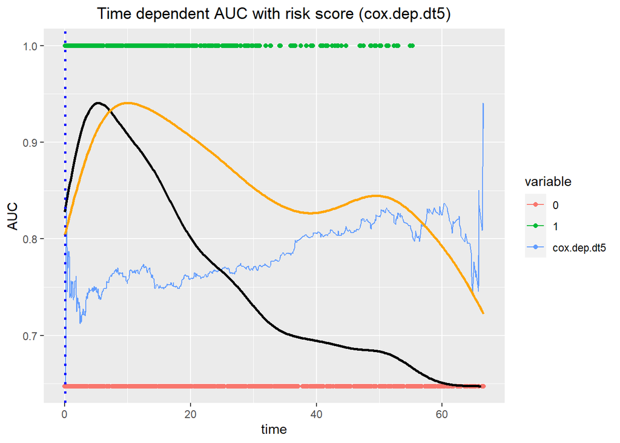

```r
dt5$censor1 <- ifelse(dt5$censor==1,
                    1,min(na.omit(ROC.risk.dep.dt5[["AUC"]])))
ggplot() +
  geom_line(data=res5, aes(x=time, y=value,
                            group=variable, color=variable)) +
  geom_point(data=dt5, aes(x=time, y=censor1, color=as.factor(censor))) +
  geom_line(data=data5_1, aes(x=time, y=density.adjusted),
            size=1, colour='black') +
  geom_line(data=data5_2, aes(x=time, y=density.adjusted),
            size=1, colour='orange') +
  scale_x_continuous(limits = c(0, max(dt5$time))) +
  geom_vline(xintercept = min(dt5$time[dt5$censor==1]),
             linetype="dotted", color = "blue", size=1) +
  ggtitle("Time dependent AUC with risk score (cox.dep.dt5)") +
  xlab("time") + ylab("AUC") +
  theme(plot.title = element_text(hjust = 0.5))
```

#### simulation (repeat 100 times / time VS mean of AUC)

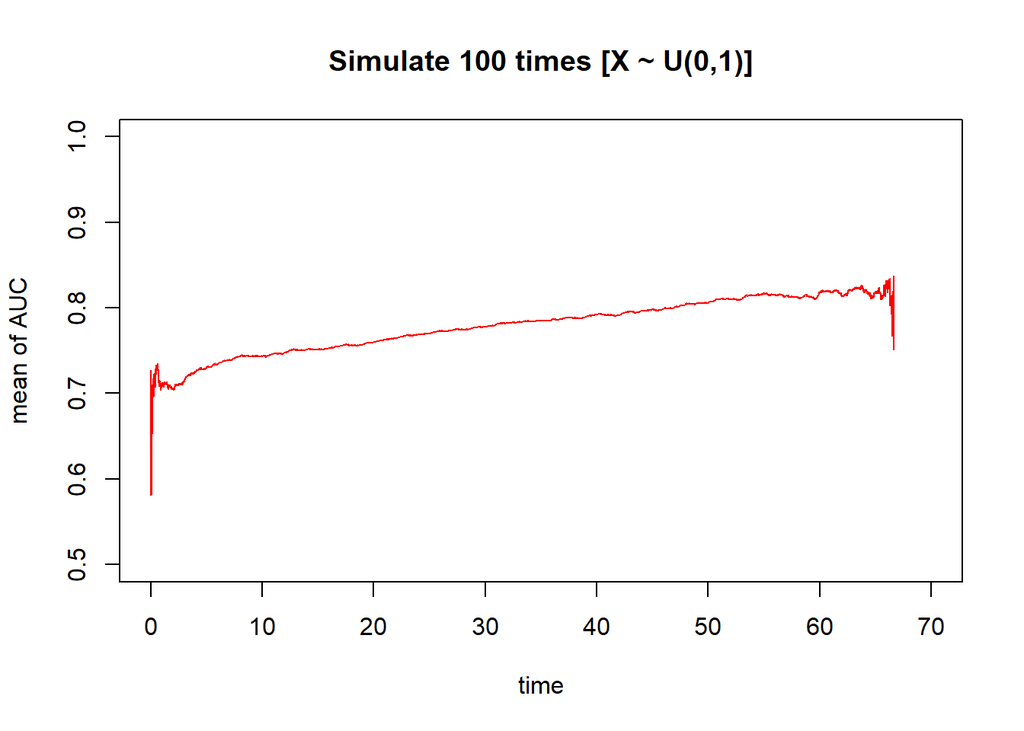

```r
con.AUC <- matrix(nrow=length(seq(0,70,0.01)),ncol=100)

for (i in 1:100) {

  # Assume parametric basis distribution is Exponential distribution...
  lambda1 <- 0.003 # parameter for generate Y
  lambda2 <- 0.2/lambda1 # parameter for generate C
  beta0 <- 3 # true coefficients
  Y <- c() # real survival time
  C <- c() # censoring time
  t <- c() # observed survival time
  censor <- c() # censoring indicator
  X <- c() # explanatory variable
  U1 <- c() # random variable from U(0,1) for generate Y
  U2 <- c() # random variable from U(0,1) for generate C


  # Generate simulation data
  set.seed(i)
  for (j in 1:200) {
    U1[j] <- runif(1)
    U2[j] <- runif(1)
    X[j] <- runif(1,min=0,max=1)
    Y[j] <- -(1/lambda1)*log(U1[j])*exp(-beta0*X[j])
    C[j] <- (lambda2)*(1-U2[j])
    t[j] <- min(Y[j],C[j])
    censor[j] <- ifelse(Y[j]<=C[j],1,0)
  }
  dt5 <- data.frame(X=X, Y=Y, C=C, time=t, censor=censor)

  # Set Cox regression model
  cox.dep.dt5 <- coxph(Surv(time,censor) ~ X, data=dt5)
  risk.dep.dt5 <- predict(object=cox.dep.dt5, newdata=dt5, type="risk") # risk score
  dt5$risk.dep.dt5 <- risk.dep.dt5
  ROC.risk.dep.dt5 <- timeROC(T=dt5$time,
                           delta=dt5$censor,marker=dt5$risk.dep.dt5,
                           cause=1,weighting="marginal",
                           times=seq(0,70,0.01))

  con.AUC[,i] <- ROC.risk.dep.dt5[["AUC"]]

  # print(i)

}

dat5 <- data.frame(time=seq(0,70,0.01), con.AUC=rowMeans(con.AUC, na.rm=TRUE))
plot(x=dat5$time, y=dat5$con.AUC, xlab="time", ylab="mean of AUC",
     main="Simulate 100 times [X ~ U(0,1)]", type="l", col="red", ylim=c(0.5,1))
```

### Case 2) X ~ Normal

- $X \sim N(0,1^2)$

### Generating simulation data

```r
# Assume parametric basis distribution is Exponential distribution...
lambda1 <- 0.003 # parameter for generate Y
lambda2 <- 0.2/lambda1 # parameter for generate C
beta0 <- 3 # true coefficients
Y <- c() # real survival time
C <- c() # censoring time
t <- c() # observed survival time
censor <- c() # censoring indicator
X <- c() # explanatory variable
U1 <- c() # random variable from U(0,1) for generate Y
U2 <- c() # random variable from U(0,1) for generate C

for (i in 1:1000) {
  U1[i] <- runif(1)
  U2[i] <- runif(1)
  X[i] <- rnorm(1,mean=0,sd=1)
  Y[i] <- -(1/lambda1)*log(U1[i])*exp(-beta0*X[i])
  C[i] <- (lambda2)*(1-U2[i])
  t[i] <- min(Y[i],C[i])
  censor[i] <- ifelse(Y[i]<=C[i],1,0)
}

mean(1-censor) # censoring rate
```

```
## [1] 0.72
```

```r
dt5 <- data.frame(X=X, Y=Y, C=C, time=t, censor=censor)
head(dt5,10)
```

```
##             X            Y         C      time censor
## 1  -1.0185647 24416.695419 28.019634 28.019634      0
## 2  -0.6512877  4493.753625  5.777158  5.777158      0
## 3   1.0318997     6.519388 56.720375  6.519388      1
## 4   0.3771917    63.854540  8.457676  8.457676      0
## 5   0.5202194   246.553643 42.876055 42.876055      0
## 6  -0.8024887   803.584965 15.048059 15.048059      0
## 7  -0.2109543   732.335020  6.828415  6.828415      0
## 8   0.2994796   154.051764 57.506886 57.506886      0
## 9  -0.4390121  1617.804152 54.252869 54.252869      0
## 10  0.7808050    46.315190  4.476891  4.476891      0
```

```r
min(dt5$time[dt5$censor==1])
```

```
## [1] 0.00337523
```

### Time dependent AUC

### Set Cox regression model

```r
cox.dep.dt5 <- coxph(Surv(time,censor) ~ X, data=dt5)
summary(cox.dep.dt5)
```

```
## Call:
## coxph(formula = Surv(time, censor) ~ X, data = dt5)
##
##   n= 1000, number of events= 280
##
##      coef exp(coef) se(coef)     z Pr(>|z|)
## X  2.9833   19.7528   0.1282 23.28   <2e-16 ***
## ---
## Signif. codes:  0 '***' 0.001 '**' 0.01 '*' 0.05 '.' 0.1 ' ' 1
##
##   exp(coef) exp(-coef) lower .95 upper .95
## X     19.75    0.05063     15.37     25.39
##
## Concordance= 0.919  (se = 0.007 )
## Likelihood ratio test= 885.7  on 1 df,   p=<2e-16
## Wald test            = 541.9  on 1 df,   p=<2e-16
## Score (logrank) test = 646.6  on 1 df,   p=<2e-16
```

```r
risk.dep.dt5 <- predict(object=cox.dep.dt5, newdata=dt5, type="risk") # risk score
dt5$risk.dep.dt5 <- risk.dep.dt5
ROC.risk.dep.dt5 <- timeROC(T=dt5$time,
                         delta=dt5$censor,marker=dt5$risk.dep.dt5,
                         cause=1,weighting="marginal",
                         times=dt5$time)
ROC.risk.dep.dt5
```

```
## Time-dependent-Roc curve estimated using IPCW  (n=1000, without competing risks).
##                       Cases Survivors Censored AUC (%)
## t=0.00337522975378996     0       999        1      NA
## t=6.64968730022239      151       749      100   95.42
## t=22.4468324787257      226       500      274   95.13
## t=42.2455415595323      271       250      479   94.19
## t=66.6533965927859      280         0      720      NA
##
## Method used for estimating IPCW:marginal
##
## Total computation time : 0.62  secs.
```

#### Make AUC data

```r
# uncensored
uncensored.density5 <- density(dt5$time[dt5$censor==1])
data5_1 <- data.frame(time=uncensored.density5[["x"]],
                    density=uncensored.density5[["y"]])
data5_1$density.adjusted <- (max(na.omit(ROC.risk.dep.dt5[["AUC"]]))-min(na.omit(ROC.risk.dep.dt5[["AUC"]])))*(uncensored.density5[["y"]]-min(uncensored.density5[["y"]]))/(max(uncensored.density5[["y"]])-min(uncensored.density5[["y"]]))+min(na.omit(ROC.risk.dep.dt5[["AUC"]]))

# censored
censored.density5 <- density(dt5$time[dt5$censor==0])
data5_2 <- data.frame(time=censored.density5[["x"]],
                    density=censored.density5[["y"]])
data5_2$density.adjusted <- (max(na.omit(ROC.risk.dep.dt5[["AUC"]]))-min(na.omit(ROC.risk.dep.dt5[["AUC"]])))*(censored.density5[["y"]]-min(censored.density5[["y"]]))/(max(censored.density5[["y"]])-min(censored.density5[["y"]]))+min(na.omit(ROC.risk.dep.dt5[["AUC"]]))

res5 <- data.frame(time=ROC.risk.dep.dt5[["times"]],
                    cox.dep.dt5=ROC.risk.dep.dt5[["AUC"]])
res5 <- melt(data = res5,
                   id.vars = "time",
                   measure.vars = c("cox.dep.dt5"))
```

#### Time dependent AUC plot with ggplot2 (cox.dep.dt5)

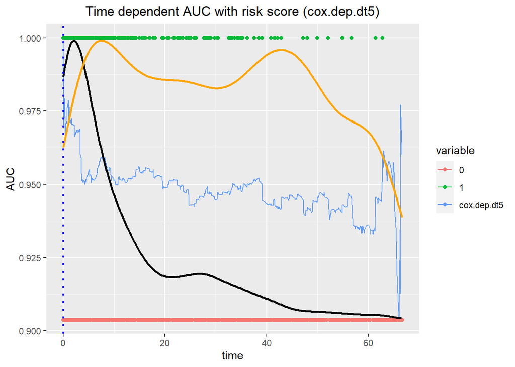

```r
dt5$censor1 <- ifelse(dt5$censor==1,
                    1,min(na.omit(ROC.risk.dep.dt5[["AUC"]])))
ggplot() +
  geom_line(data=res5, aes(x=time, y=value,
                            group=variable, color=variable)) +
  geom_point(data=dt5, aes(x=time, y=censor1, color=as.factor(censor))) +
  geom_line(data=data5_1, aes(x=time, y=density.adjusted),
            size=1, colour='black') +
  geom_line(data=data5_2, aes(x=time, y=density.adjusted),
            size=1, colour='orange') +
  scale_x_continuous(limits = c(0, max(dt5$time))) +
  geom_vline(xintercept = min(dt5$time[dt5$censor==1]),
             linetype="dotted", color = "blue", size=1) +
  ggtitle("Time dependent AUC with risk score (cox.dep.dt5)") +
  xlab("time") + ylab("AUC") +
  theme(plot.title = element_text(hjust = 0.5))
```

#### simulation (repeat 100 times / time VS mean of AUC)

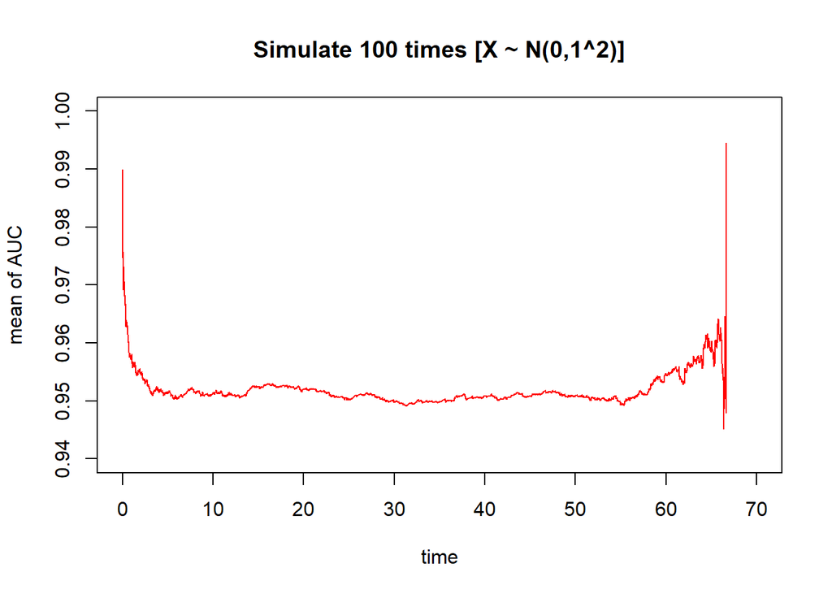

```r
con.AUC <- matrix(nrow=length(seq(0,70,0.01)),ncol=100)

for (i in 1:100) {

  # Assume parametric basis distribution is Exponential distribution...
  lambda1 <- 0.003 # parameter for generate Y
  lambda2 <- 0.2/lambda1 # parameter for generate C
  beta0 <- 3 # true coefficients
  Y <- c() # real survival time
  C <- c() # censoring time
  t <- c() # observed survival time
  censor <- c() # censoring indicator
  X <- c() # explanatory variable
  U1 <- c() # random variable from U(0,1) for generate Y
  U2 <- c() # random variable from U(0,1) for generate C


  # Generate simulation data
  set.seed(i)
  for (j in 1:200) {
    U1[j] <- runif(1)
    U2[j] <- runif(1)
    X[j] <- rnorm(1,mean=0,sd=1)
    Y[j] <- -(1/lambda1)*log(U1[j])*exp(-beta0*X[j])
    C[j] <- (lambda2)*(1-U2[j])
    t[j] <- min(Y[j],C[j])
    censor[j] <- ifelse(Y[j]<=C[j],1,0)
  }
  dt5 <- data.frame(X=X, Y=Y, C=C, time=t, censor=censor)

  # Set Cox regression model
  cox.dep.dt5 <- coxph(Surv(time,censor) ~ X, data=dt5)
  risk.dep.dt5 <- predict(object=cox.dep.dt5, newdata=dt5, type="risk") # risk score
  dt5$risk.dep.dt5 <- risk.dep.dt5
  ROC.risk.dep.dt5 <- timeROC(T=dt5$time,
                           delta=dt5$censor,marker=dt5$risk.dep.dt5,
                           cause=1,weighting="marginal",
                           times=seq(0,70,0.01))

  con.AUC[,i] <- ROC.risk.dep.dt5[["AUC"]]

  # print(i)

}

dat5 <- data.frame(time=seq(0,70,0.01), con.AUC=rowMeans(con.AUC, na.rm=TRUE))
plot(x=dat5$time, y=dat5$con.AUC, xlab="time", ylab="mean of AUC",
     main="Simulate 100 times [X ~ N(0,1^2)]", type="l", col="red", ylim=c(0.94,1))
```

### Case 3) X ~ Cauchy

- $X \sim Cauchy(0,1)$

### Generating simulation data

```r
# Assume parametric basis distribution is Exponential distribution...
lambda1 <- 0.003 # parameter for generate Y
lambda2 <- 0.2/lambda1 # parameter for generate C
beta0 <- 3 # true coefficients
Y <- c() # real survival time
C <- c() # censoring time
t <- c() # observed survival time
censor <- c() # censoring indicator
X <- c() # explanatory variable
U1 <- c() # random variable from U(0,1) for generate Y
U2 <- c() # random variable from U(0,1) for generate C

for (i in 1:1000) {
  U1[i] <- runif(1)
  U2[i] <- runif(1)
  X[i] <- rcauchy(1,location=0,scale=1)
  Y[i] <- -(1/lambda1)*log(U1[i])*exp(-beta0*X[i])
  C[i] <- (lambda2)*(1-U2[i])
  t[i] <- min(Y[i],C[i])
  censor[i] <- ifelse(Y[i]<=C[i],1,0)
}

mean(1-censor) # censoring rate
```

```
## [1] 0.659
```

```r
dt5 <- data.frame(X=X, Y=Y, C=C, time=t, censor=censor)
head(dt5,10)
```

```
##             X            Y         C         time censor
## 1   5.5872575 4.042345e-05 51.337728 4.042345e-05      1
## 2   0.1405805 1.447843e+02  5.007050 5.007050e+00      0
## 3   0.5212785 1.327692e+02 10.121741 1.012174e+01      0
## 4  -1.8979084 1.904867e+04  9.120525 9.120525e+00      0
## 5   0.5002505 2.836323e+02  0.137130 1.371300e-01      0
## 6   1.8753358 2.995547e+00 13.487119 2.995547e+00      1
## 7  -0.4673821 4.289083e+02 43.930028 4.393003e+01      0
## 8  -0.3195434 7.810396e+02 28.762635 2.876264e+01      0
## 9   3.6117899 4.392696e-04 10.186662 4.392696e-04      1
## 10 -0.3118593 8.981394e+02 36.206774 3.620677e+01      0
```

```r
min(dt5$time[dt5$censor==1])
```

```
## [1] 0
```

### Time dependent AUC

### Set Cox regression model

```r
cox.dep.dt5 <- coxph(Surv(time,censor) ~ X, data=dt5)
summary(cox.dep.dt5)
```

```
## Call:
## coxph(formula = Surv(time, censor) ~ X, data = dt5)
##
##   n= 1000, number of events= 341
##
##        coef exp(coef)  se(coef)     z Pr(>|z|)
## X 0.0009456 1.0009460 0.0001524 6.204 5.52e-10 ***
## ---
## Signif. codes:  0 '***' 0.001 '**' 0.01 '*' 0.05 '.' 0.1 ' ' 1
##
##   exp(coef) exp(-coef) lower .95 upper .95
## X     1.001     0.9991     1.001     1.001
##
## Concordance= 0.961  (se = 0.004 )
## Likelihood ratio test= 16  on 1 df,   p=6e-05
## Wald test            = 38.48  on 1 df,   p=6e-10
## Score (logrank) test = 0.83  on 1 df,   p=0.4
```

```r
risk.dep.dt5 <- predict(object=cox.dep.dt5, newdata=dt5, type="risk") # risk score
dt5$risk.dep.dt5 <- risk.dep.dt5
ROC.risk.dep.dt5 <- timeROC(T=dt5$time,
                         delta=dt5$censor,marker=dt5$risk.dep.dt5,
                         cause=1,weighting="marginal",
                         times=dt5$time)
ROC.risk.dep.dt5
```

```
## Time-dependent-Roc curve estimated using IPCW  (n=1000, without competing risks).
##                    Cases Survivors Censored AUC (%)
## t=0                    0       997        3      NA
## t=2.76917529602846   207       749       44   98.93
## t=16.5681104796628   296       500      204   97.63
## t=37.0635492935345   330       250      420   97.05
## t=66.5934410256644   341         0      659      NA
##
## Method used for estimating IPCW:marginal
##
## Total computation time : 0.43  secs.
```

#### Make AUC data

```r
# uncensored
uncensored.density5 <- density(dt5$time[dt5$censor==1])
data5_1 <- data.frame(time=uncensored.density5[["x"]],
                    density=uncensored.density5[["y"]])
data5_1$density.adjusted <- (max(na.omit(ROC.risk.dep.dt5[["AUC"]]))-min(na.omit(ROC.risk.dep.dt5[["AUC"]])))*(uncensored.density5[["y"]]-min(uncensored.density5[["y"]]))/(max(uncensored.density5[["y"]])-min(uncensored.density5[["y"]]))+min(na.omit(ROC.risk.dep.dt5[["AUC"]]))

# censored
censored.density5 <- density(dt5$time[dt5$censor==0])
data5_2 <- data.frame(time=censored.density5[["x"]],
                    density=censored.density5[["y"]])
data5_2$density.adjusted <- (max(na.omit(ROC.risk.dep.dt5[["AUC"]]))-min(na.omit(ROC.risk.dep.dt5[["AUC"]])))*(censored.density5[["y"]]-min(censored.density5[["y"]]))/(max(censored.density5[["y"]])-min(censored.density5[["y"]]))+min(na.omit(ROC.risk.dep.dt5[["AUC"]]))

res5 <- data.frame(time=ROC.risk.dep.dt5[["times"]],
                    cox.dep.dt5=ROC.risk.dep.dt5[["AUC"]])
res5 <- melt(data = res5,
                   id.vars = "time",
                   measure.vars = c("cox.dep.dt5"))
```

#### Time dependent AUC plot with ggplot2 (cox.dep.dt5)

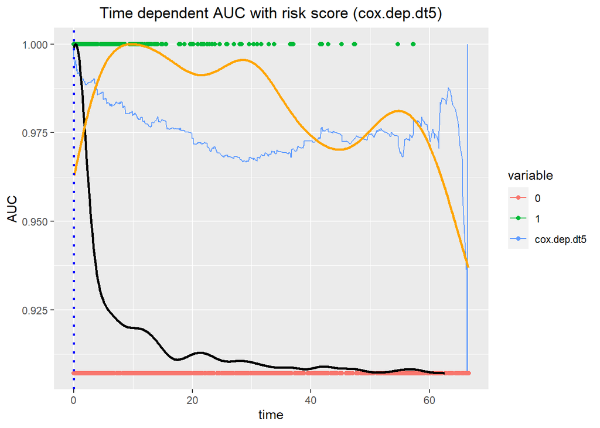

```r
dt5$censor1 <- ifelse(dt5$censor==1,
                    1,min(na.omit(ROC.risk.dep.dt5[["AUC"]])))
ggplot() +
  geom_line(data=res5, aes(x=time, y=value,
                            group=variable, color=variable)) +
  geom_point(data=dt5, aes(x=time, y=censor1, color=as.factor(censor))) +
  geom_line(data=data5_1, aes(x=time, y=density.adjusted),
            size=1, colour='black') +
  geom_line(data=data5_2, aes(x=time, y=density.adjusted),
            size=1, colour='orange') +
  scale_x_continuous(limits = c(0, max(dt5$time))) +
  geom_vline(xintercept = min(dt5$time[dt5$censor==1]),
             linetype="dotted", color = "blue", size=1) +
  ggtitle("Time dependent AUC with risk score (cox.dep.dt5)") +
  xlab("time") + ylab("AUC") +
  theme(plot.title = element_text(hjust = 0.5))
```

#### simulation (repeat 100 times / time VS mean of AUC)

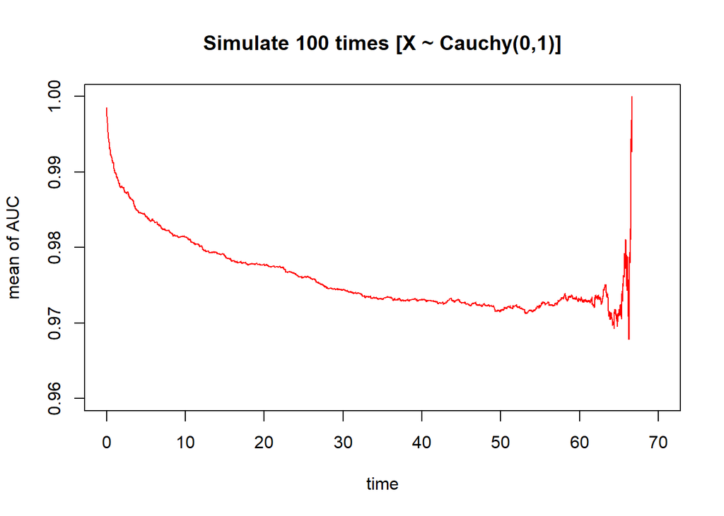

```r
con.AUC <- matrix(nrow=length(seq(0,70,0.01)),ncol=100)

for (i in 1:100) {

  # Assume parametric basis distribution is Exponential distribution...
  lambda1 <- 0.003 # parameter for generate Y
  lambda2 <- 0.2/lambda1 # parameter for generate C
  beta0 <- 3 # true coefficients
  Y <- c() # real survival time
  C <- c() # censoring time
  t <- c() # observed survival time
  censor <- c() # censoring indicator
  X <- c() # explanatory variable
  U1 <- c() # random variable from U(0,1) for generate Y
  U2 <- c() # random variable from U(0,1) for generate C


  # Generate simulation data
  set.seed(i)
  for (j in 1:200) {
    U1[j] <- runif(1)
    U2[j] <- runif(1)
    X[j] <- rcauchy(1,location=0,scale=1)
    Y[j] <- -(1/lambda1)*log(U1[j])*exp(-beta0*X[j])
    C[j] <- (lambda2)*(1-U2[j])
    t[j] <- min(Y[j],C[j])
    censor[j] <- ifelse(Y[j]<=C[j],1,0)
  }
  dt5 <- data.frame(X=X, Y=Y, C=C, time=t, censor=censor)

  # Set Cox regression model
  cox.dep.dt5 <- coxph(Surv(time,censor) ~ X, data=dt5)
  risk.dep.dt5 <- predict(object=cox.dep.dt5, newdata=dt5, type="risk") # risk score
  dt5$risk.dep.dt5 <- risk.dep.dt5
  ROC.risk.dep.dt5 <- timeROC(T=dt5$time,
                           delta=dt5$censor,marker=dt5$risk.dep.dt5,
                           cause=1,weighting="marginal",
                           times=seq(0,70,0.01))

  con.AUC[,i] <- ROC.risk.dep.dt5[["AUC"]]

  # print(i)

}

dat5 <- data.frame(time=seq(0,70,0.01), con.AUC=rowMeans(con.AUC, na.rm=TRUE))
plot(x=dat5$time, y=dat5$con.AUC, xlab="time", ylab="mean of AUC",
     main="Simulate 100 times [X ~ Cauchy(0,1)]", type="l", col="red", ylim=c(0.96,1))
```

### Case 4) X ~ Exponential

- $X \sim Exp(1)$

### Generating simulation data

```r
# Assume parametric basis distribution is Exponential distribution...
lambda1 <- 0.003 # parameter for generate Y
lambda2 <- 0.2/lambda1 # parameter for generate C
beta0 <- 3 # true coefficients
Y <- c() # real survival time
C <- c() # censoring time
t <- c() # observed survival time
censor <- c() # censoring indicator
X <- c() # explanatory variable
U1 <- c() # random variable from U(0,1) for generate Y
U2 <- c() # random variable from U(0,1) for generate C

for (i in 1:1000) {
  U1[i] <- runif(1)
  U2[i] <- runif(1)
  X[i] <- rexp(1,rate=1)
  Y[i] <- -(1/lambda1)*log(U1[i])*exp(-beta0*X[i])
  C[i] <- (lambda2)*(1-U2[i])
  t[i] <- min(Y[i],C[i])
  censor[i] <- ifelse(Y[i]<=C[i],1,0)
}

mean(1-censor) # censoring rate
```

```
## [1] 0.447
```

```r
dt5 <- data.frame(X=X, Y=Y, C=C, time=t, censor=censor)
head(dt5,10)
```

```
##            X           Y        C       time censor
## 1  1.6199331   8.9131625 28.01963  8.9131625      1
## 2  0.1784372 405.4067104 56.80095 56.8009459      0
## 3  0.2034422  78.2691065 56.72038 56.7203753      0
## 4  1.2818807   0.9665096 23.53437  0.9665096      1
## 5  0.3970893 356.7266370 42.87606 42.8760553      0
## 6  0.5485582  77.5267229 13.00853 13.0085340      0
## 7  0.9386417  31.0270225 41.52244 31.0270225      1
## 8  0.6717680   4.8007404 38.90257  4.8007404      1
## 9  0.2354258 186.6900751 57.50689 57.5068861      0
## 10 1.8759501   0.4704266 48.50453  0.4704266      1
```

```r
min(dt5$time[dt5$censor==1])
```

```
## [1] 2.400192e-06
```

### Time dependent AUC

### Set Cox regression model

```r
cox.dep.dt5 <- coxph(Surv(time,censor) ~ X, data=dt5)
summary(cox.dep.dt5)
```

```
## Call:
## coxph(formula = Surv(time, censor) ~ X, data = dt5)
##
##   n= 1000, number of events= 553
##
##      coef exp(coef) se(coef)     z Pr(>|z|)
## X  2.9370   18.8587   0.0933 31.48   <2e-16 ***
## ---
## Signif. codes:  0 '***' 0.001 '**' 0.01 '*' 0.05 '.' 0.1 ' ' 1
##
##   exp(coef) exp(-coef) lower .95 upper .95
## X     18.86    0.05303     15.71     22.64
##
## Concordance= 0.877  (se = 0.008 )
## Likelihood ratio test= 1414  on 1 df,   p=<2e-16
## Wald test            = 991  on 1 df,   p=<2e-16
## Score (logrank) test = 1962  on 1 df,   p=<2e-16
```

```r
risk.dep.dt5 <- predict(object=cox.dep.dt5, newdata=dt5, type="risk") # risk score
dt5$risk.dep.dt5 <- risk.dep.dt5
ROC.risk.dep.dt5 <- timeROC(T=dt5$time,
                         delta=dt5$censor,marker=dt5$risk.dep.dt5,
                         cause=1,weighting="marginal",
                         times=dt5$time)
ROC.risk.dep.dt5
```

```
## Time-dependent-Roc curve estimated using IPCW  (n=1000, without competing risks).
##                        Cases Survivors Censored AUC (%)
## t=2.40019163067318e-06     0       999        1      NA
## t=1.77167275272023       233       749       18   94.12
## t=11.2183211559663       392       500      108   91.93
## t=27.3310660229375       502       250      248   90.32
## t=66.6367447003722       553         0      447      NA
##
## Method used for estimating IPCW:marginal
##
## Total computation time : 0.64  secs.
```

#### Make AUC data

```r
# uncensored
uncensored.density5 <- density(dt5$time[dt5$censor==1])
data5_1 <- data.frame(time=uncensored.density5[["x"]],
                    density=uncensored.density5[["y"]])
data5_1$density.adjusted <- (max(na.omit(ROC.risk.dep.dt5[["AUC"]]))-min(na.omit(ROC.risk.dep.dt5[["AUC"]])))*(uncensored.density5[["y"]]-min(uncensored.density5[["y"]]))/(max(uncensored.density5[["y"]])-min(uncensored.density5[["y"]]))+min(na.omit(ROC.risk.dep.dt5[["AUC"]]))

# censored
censored.density5 <- density(dt5$time[dt5$censor==0])
data5_2 <- data.frame(time=censored.density5[["x"]],
                    density=censored.density5[["y"]])
data5_2$density.adjusted <- (max(na.omit(ROC.risk.dep.dt5[["AUC"]]))-min(na.omit(ROC.risk.dep.dt5[["AUC"]])))*(censored.density5[["y"]]-min(censored.density5[["y"]]))/(max(censored.density5[["y"]])-min(censored.density5[["y"]]))+min(na.omit(ROC.risk.dep.dt5[["AUC"]]))

res5 <- data.frame(time=ROC.risk.dep.dt5[["times"]],
                    cox.dep.dt5=ROC.risk.dep.dt5[["AUC"]])
res5 <- melt(data = res5,
                   id.vars = "time",
                   measure.vars = c("cox.dep.dt5"))
```

#### Time dependent AUC plot with ggplot2 (cox.dep.dt5)

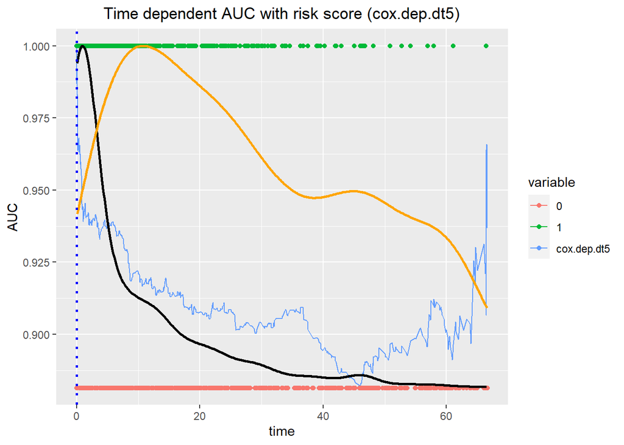

```r
dt5$censor1 <- ifelse(dt5$censor==1,
                    1,min(na.omit(ROC.risk.dep.dt5[["AUC"]])))
ggplot() +
  geom_line(data=res5, aes(x=time, y=value,
                            group=variable, color=variable)) +
  geom_point(data=dt5, aes(x=time, y=censor1, color=as.factor(censor))) +
  geom_line(data=data5_1, aes(x=time, y=density.adjusted),
            size=1, colour='black') +
  geom_line(data=data5_2, aes(x=time, y=density.adjusted),
            size=1, colour='orange') +
  scale_x_continuous(limits = c(0, max(dt5$time))) +
  geom_vline(xintercept = min(dt5$time[dt5$censor==1]),
             linetype="dotted", color = "blue", size=1) +
  ggtitle("Time dependent AUC with risk score (cox.dep.dt5)") +
  xlab("time") + ylab("AUC") +
  theme(plot.title = element_text(hjust = 0.5))
```

#### simulation (repeat 100 times / time VS mean of AUC)

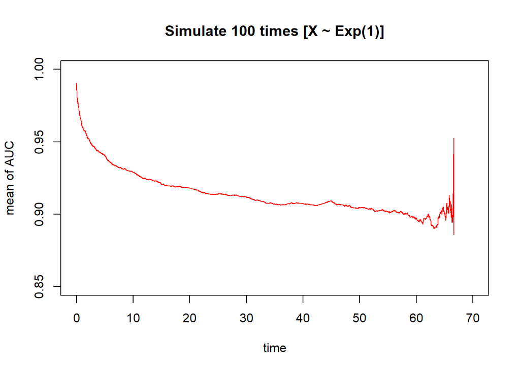

```r
con.AUC <- matrix(nrow=length(seq(0,70,0.01)),ncol=100)

for (i in 1:100) {

  # Assume parametric basis distribution is Exponential distribution...
  lambda1 <- 0.003 # parameter for generate Y
  lambda2 <- 0.2/lambda1 # parameter for generate C
  beta0 <- 3 # true coefficients
  Y <- c() # real survival time
  C <- c() # censoring time
  t <- c() # observed survival time
  censor <- c() # censoring indicator
  X <- c() # explanatory variable
  U1 <- c() # random variable from U(0,1) for generate Y
  U2 <- c() # random variable from U(0,1) for generate C


  # Generate simulation data
  set.seed(i)
  for (j in 1:200) {
    U1[j] <- runif(1)
    U2[j] <- runif(1)
    X[j] <- rexp(1,rate=1)
    Y[j] <- -(1/lambda1)*log(U1[j])*exp(-beta0*X[j])
    C[j] <- (lambda2)*(1-U2[j])
    t[j] <- min(Y[j],C[j])
    censor[j] <- ifelse(Y[j]<=C[j],1,0)
  }
  dt5 <- data.frame(X=X, Y=Y, C=C, time=t, censor=censor)

  # Set Cox regression model
  cox.dep.dt5 <- coxph(Surv(time,censor) ~ X, data=dt5)
  risk.dep.dt5 <- predict(object=cox.dep.dt5, newdata=dt5, type="risk") # risk score
  dt5$risk.dep.dt5 <- risk.dep.dt5
  ROC.risk.dep.dt5 <- timeROC(T=dt5$time,
                           delta=dt5$censor,marker=dt5$risk.dep.dt5,
                           cause=1,weighting="marginal",
                           times=seq(0,70,0.01))

  con.AUC[,i] <- ROC.risk.dep.dt5[["AUC"]]

  # print(i)

}

dat5 <- data.frame(time=seq(0,70,0.01), con.AUC=rowMeans(con.AUC, na.rm=TRUE))
plot(x=dat5$time, y=dat5$con.AUC, xlab="time", ylab="mean of AUC",
     main="Simulate 100 times [X ~ Exp(1)]", type="l", col="red", ylim=c(0.85,1))
```

# Generate survival data with time dependent covariates

## Background

- reference 1 : https://doi.org/10.1002/sim.5452
- reference 2 : https://dx.doi.org/10.21037/atm.2018.02.12

## Continuous time-varying covariate: exponential distribution of event times

- $Y$ : real survival time
- $C$ : censoring time
- model : $h(t,x,z(t))=h_{0}(t)exp(\beta x + \gamma z(t))$
- $Y$ : Assume $z(t)=\alpha t$, $\alpha > 0$
- $h_{0}(t)=\lambda$
- $h(t,x,z(t))=\lambda exp(\beta x + \gamma \alpha t)=-\frac{d}{dt} log[S(t,x,z(t))]$
- $log[S(t,x,z(t))]=-\int_{0}^{t}\lambda exp(\beta x + \gamma \alpha s)ds=-\frac{\lambda exp(\beta x)}{\gamma \alpha} [exp(\gamma \alpha t)-1]$
- $S(t,x,z(t))=exp[-\frac{\lambda exp(\beta x)}{\gamma \alpha} [exp(\gamma \alpha t)-1]]$
- $F(t,x,z(t))=1-exp[-\frac{\lambda exp(\beta x)}{\gamma \alpha} [exp(\gamma \alpha t)-1]]$
- $F^{-1}(t,x,z(t))=\frac {1}{\gamma \alpha} log[1-\frac {\gamma \alpha}{\lambda exp(\beta x)} log(1-t)]$
- $C$ : $f_{C0}(t)=\frac {1}{\lambda}, 0<t<\lambda$ -> $S_{C0}(t)=1-\frac {t}{\lambda}$ -> $h_{C0}(t)=\frac {1}{\lambda -t}$
- By Inverse Transform Sampling and non-informative censoring, suppose that $U_{1}, U_{2} \overset{i.i.d}{\sim}\ U(0,1)$, then we can generate real survival time $Y$ and censoring time $C$ like this.
- $\therefore Y=\frac {1}{\gamma \alpha} log[1-\frac {\gamma \alpha}{\lambda_{1} exp(\beta x)} log(U_{1})]$
- $\therefore C=\lambda_{2}(1-U_{2})$

## True model

- model : $h(t,x,z(t))=h_{0}(t)exp[\beta x + \gamma z(t)]$
- $z(t)=\alpha t$
- $h_{0}(t)=\lambda$
- True coefficients : $\beta=3$, $\gamma=2$, $\alpha=4$

## Case 1) X ~ Uniform

- $X \sim U(0,1)$

## Generating simulation data

```r
lambda1 <- 0.003 # parameter for generate Y
lambda2 <- 0.2/lambda1 # parameter for generate C
beta0 <- 3 ; gamma0 <- 2 ; alpha0 <- 4 # true coefficients
Y <- c() # real survival time
C <- c() # censoring time
t <- c() # observed survival time
censor <- c() # censoring indicator
X <- c() # time invariant covariate
U1 <- c() # random variable from U(0,1) for generate Y
U2 <- c() # random variable from U(0,1) for generate C

for (i in 1:1000) {
  U1[i] <- runif(1)
  U2[i] <- runif(1)
  X[i] <- runif(1,min=0,max=1)
  Y[i] <- (1/gamma0*alpha0)*log(1-(gamma0*alpha0/lambda1/exp(beta0*X[i]))*log(U1[i]))
  C[i] <- (lambda2)*(1-U2[i])
  t[i] <- min(Y[i],C[i])
  censor[i] <- ifelse(Y[i]<=C[i],1,0)
}

mean(1-censor) # censoring rate
```

```
## [1] 0.182
```

```r
dt5 <- data.frame(X=X, Y=Y, C=C, time=t, censor=censor)
head(dt5,10)
```

```
##             X         Y        C      time censor
## 1  0.38075636 14.178923 27.39111 14.178923      1
## 2  0.59845486 10.093809 58.93062 10.093809      1
## 3  0.31616703 10.313984 43.27573 10.313984      1
## 4  0.84020015  7.986237 49.68067  7.986237      1
## 5  0.45804693 10.534489 46.08118 10.534489      1
## 6  0.13561655 14.708453 44.99893 14.708453      1
## 7  0.83792294  6.120731 56.64101  6.120731      1
## 8  0.04422934 14.519038 58.93648 14.519038      1
## 9  0.83694795 11.230379  7.91575  7.915750      0
## 10 0.31663633 15.973670 63.41860 15.973670      1
```

```r
min(dt5$time[dt5$censor==1])
```

```
## [1] 0.3547137
```

### Time dependent AUC

### Set Cox regression model

```r
cox.dep.dt5 <- coxph(Surv(time,censor) ~ X, data=dt5)
summary(cox.dep.dt5)
```

```
## Call:
## coxph(formula = Surv(time, censor) ~ X, data = dt5)
##
##   n= 1000, number of events= 818
##
##      coef exp(coef) se(coef)     z Pr(>|z|)
## X  2.9879   19.8447   0.1544 19.35   <2e-16 ***
## ---
## Signif. codes:  0 '***' 0.001 '**' 0.01 '*' 0.05 '.' 0.1 ' ' 1
##
##   exp(coef) exp(-coef) lower .95 upper .95
## X     19.84    0.05039     14.66     26.86
##
## Concordance= 0.711  (se = 0.009 )
## Likelihood ratio test= 387.8  on 1 df,   p=<2e-16
## Wald test            = 374.4  on 1 df,   p=<2e-16
## Score (logrank) test = 405.6  on 1 df,   p=<2e-16
```

```r
risk.dep.dt5 <- predict(object=cox.dep.dt5, newdata=dt5, type="risk") # risk score
dt5$risk.dep.dt5 <- risk.dep.dt5
ROC.risk.dep.dt5 <- timeROC(T=dt5$time,
                         delta=dt5$censor,marker=dt5$risk.dep.dt5,
                         cause=1,weighting="marginal",
                         times=dt5$time)
ROC.risk.dep.dt5
```

```
## Time-dependent-Roc curve estimated using IPCW  (n=1000, without competing risks).
##                      Cases Survivors Censored AUC (%)
## t=0.0318772159516811     0       999        1      NA
## t=8.34319057285382     127       749      124   76.67
## t=11.1119285359163     341       500      159   78.36
## t=13.3213358310362     577       250      173   81.68
## t=18.1380257256295     817         0      183      NA
##
## Method used for estimating IPCW:marginal
##
## Total computation time : 0.64  secs.
```

#### Make AUC data

```r
# uncensored
uncensored.density5 <- density(dt5$time[dt5$censor==1])
data5_1 <- data.frame(time=uncensored.density5[["x"]],
                    density=uncensored.density5[["y"]])
data5_1$density.adjusted <- (max(na.omit(ROC.risk.dep.dt5[["AUC"]]))-min(na.omit(ROC.risk.dep.dt5[["AUC"]])))*(uncensored.density5[["y"]]-min(uncensored.density5[["y"]]))/(max(uncensored.density5[["y"]])-min(uncensored.density5[["y"]]))+min(na.omit(ROC.risk.dep.dt5[["AUC"]]))

# censored
censored.density5 <- density(dt5$time[dt5$censor==0])
data5_2 <- data.frame(time=censored.density5[["x"]],
                    density=censored.density5[["y"]])
data5_2$density.adjusted <- (max(na.omit(ROC.risk.dep.dt5[["AUC"]]))-min(na.omit(ROC.risk.dep.dt5[["AUC"]])))*(censored.density5[["y"]]-min(censored.density5[["y"]]))/(max(censored.density5[["y"]])-min(censored.density5[["y"]]))+min(na.omit(ROC.risk.dep.dt5[["AUC"]]))

res5 <- data.frame(time=ROC.risk.dep.dt5[["times"]],
                    cox.dep.dt5=ROC.risk.dep.dt5[["AUC"]])
res5 <- melt(data = res5,
                   id.vars = "time",
                   measure.vars = c("cox.dep.dt5"))
```

#### Time dependent AUC plot with ggplot2 (cox.dep.dt5)

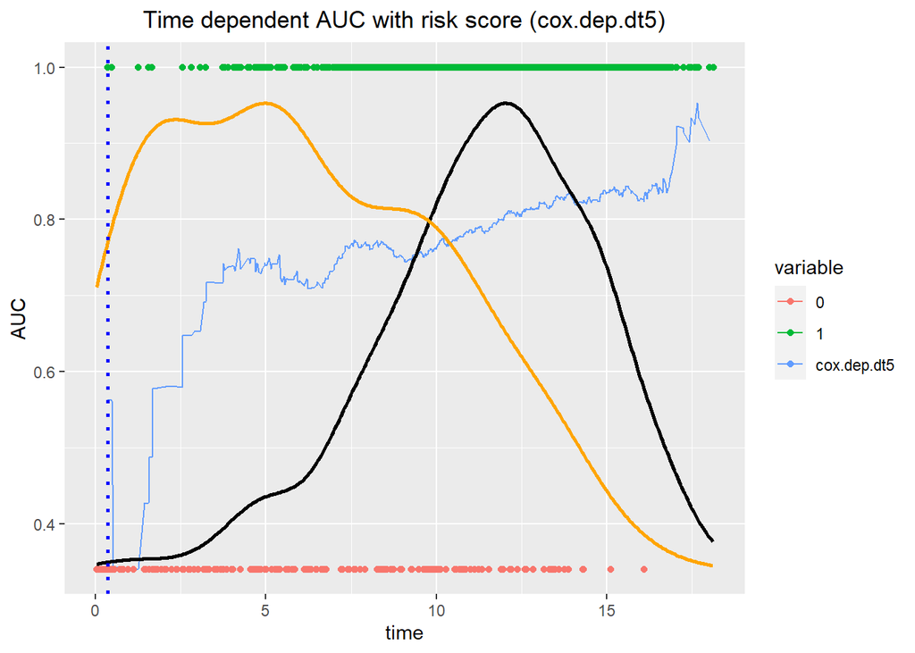

```r
dt5$censor1 <- ifelse(dt5$censor==1,
                    1,min(na.omit(ROC.risk.dep.dt5[["AUC"]])))
ggplot() +
  geom_line(data=res5, aes(x=time, y=value,
                            group=variable, color=variable)) +
  geom_point(data=dt5, aes(x=time, y=censor1, color=as.factor(censor))) +
  geom_line(data=data5_1, aes(x=time, y=density.adjusted),
            size=1, colour='black') +
  geom_line(data=data5_2, aes(x=time, y=density.adjusted),
            size=1, colour='orange') +
  scale_x_continuous(limits = c(0, max(dt5$time))) +
  geom_vline(xintercept = min(dt5$time[dt5$censor==1]),
             linetype="dotted", color = "blue", size=1) +
  ggtitle("Time dependent AUC with risk score (cox.dep.dt5)") +
  xlab("time") + ylab("AUC") +
  theme(plot.title = element_text(hjust = 0.5))
```

#### simulation (repeat 100 times / time VS mean of AUC)

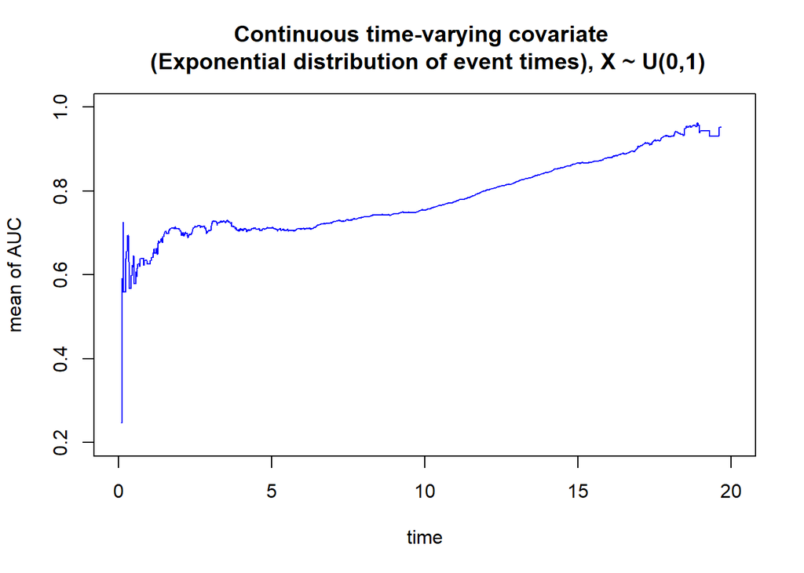

```r
con.AUC <- matrix(nrow=length(seq(0,20,0.01)),ncol=100)

for (i in 1:100) {

  lambda1 <- 0.003 # parameter for generate Y
  lambda2 <- 0.2/lambda1 # parameter for generate C
  beta0 <- 3 ; gamma0 <- 2 ; alpha0 <- 4 # true coefficients
  Y <- c() # real survival time
  C <- c() # censoring time
  t <- c() # observed survival time
  censor <- c() # censoring indicator
  X <- c() # time invariant covariate
  U1 <- c() # random variable from U(0,1) for generate Y
  U2 <- c() # random variable from U(0,1) for generate C

  # Generate simulation data
  set.seed(i)
  for (j in 1:200) {
    U1[j] <- runif(1)
    U2[j] <- runif(1)
    X[j] <- runif(1,min=0,max=1)
    Y[j] <- (1/gamma0*alpha0)*log(1-(gamma0*alpha0/lambda1/exp(beta0*X[j]))*log(U1[j]))
    C[j] <- (lambda2)*(1-U2[j])
    t[j] <- min(Y[j],C[j])
    censor[j] <- ifelse(Y[j]<=C[j],1,0)
  }
  dt5 <- data.frame(X=X, Y=Y, C=C, time=t, censor=censor)

  # Set Cox regression model
  cox.dep.dt5 <- coxph(Surv(time,censor) ~ X, data=dt5)
  summary(cox.dep.dt5)
  risk.dep.dt5 <- predict(object=cox.dep.dt5, newdata=dt5, type="risk") # risk score
  dt5$risk.dep.dt5 <- risk.dep.dt5
  ROC.risk.dep.dt5 <- timeROC(T=dt5$time,
                           delta=dt5$censor,marker=dt5$risk.dep.dt5,
                           cause=1,weighting="marginal",
                           times=seq(0,20,0.01))

  con.AUC[,i] <- ROC.risk.dep.dt5[["AUC"]]

  # print(i)

}

dat5 <- data.frame(time=seq(0,20,0.01), con.AUC=rowMeans(con.AUC, na.rm=TRUE))
plot(x=dat5$time, y=dat5$con.AUC, xlab="time", ylab="mean of AUC",
     main="Continuous time-varying covariate \n (Exponential distribution of event times), X ~ U(0,1)", type="l", col="blue", ylim=c(0.2,1))
```

## Case 2) X ~ Normal

- $X \sim N(0,1^2)$

## Generating simulation data

```r
lambda1 <- 0.003 # parameter for generate Y
lambda2 <- 0.2/lambda1 # parameter for generate C
beta0 <- 3 ; gamma0 <- 2 ; alpha0 <- 4 # true coefficients
Y <- c() # real survival time
C <- c() # censoring time
t <- c() # observed survival time
censor <- c() # censoring indicator
X <- c() # time invariant covariate
U1 <- c() # random variable from U(0,1) for generate Y
U2 <- c() # random variable from U(0,1) for generate C

for (i in 1:1000) {
  U1[i] <- runif(1)
  U2[i] <- runif(1)
  X[i] <- rnorm(1,mean=0,sd=1)
  Y[i] <- (1/gamma0*alpha0)*log(1-(gamma0*alpha0/lambda1/exp(beta0*X[i]))*log(U1[i]))
  C[i] <- (lambda2)*(1-U2[i])
  t[i] <- min(Y[i],C[i])
  censor[i] <- ifelse(Y[i]<=C[i],1,0)
}

mean(1-censor) # censoring rate
```

```
## [1] 0.225
```

```r
dt5 <- data.frame(X=X, Y=Y, C=C, time=t, censor=censor)
head(dt5,10)
```

```
##             X         Y         C      time censor
## 1  -1.0185647 24.364938 28.019634 24.364938      1
## 2  -0.6512877 20.979826  5.777158  5.777158      0
## 3   1.0318997  7.946428 56.720375  7.946428      1
## 4   0.3771917 12.476010  8.457676  8.457676      0
## 5   0.5202194 15.175056 42.876055 15.175056      1
## 6  -0.8024887 17.537360 15.048059 15.048059      0
## 7  -0.2109543 17.351701  6.828415  6.828415      0
## 8   0.2994796 14.235083 57.506886 14.235083      1
## 9  -0.4390121 18.936688 54.252869 18.936688      1
## 10  0.7808050 11.835214  4.476891  4.476891      0
```

```r
min(dt5$time[dt5$censor==1])
```

```
## [1] 0.05328744
```

### Time dependent AUC

### Set Cox regression model

```r
cox.dep.dt5 <- coxph(Surv(time,censor) ~ X, data=dt5)
summary(cox.dep.dt5)
```

```
## Call:
## coxph(formula = Surv(time, censor) ~ X, data = dt5)
##
##   n= 1000, number of events= 775
##
##       coef exp(coef) se(coef)     z Pr(>|z|)
## X  2.95924  19.28328  0.08973 32.98   <2e-16 ***
## ---
## Signif. codes:  0 '***' 0.001 '**' 0.01 '*' 0.05 '.' 0.1 ' ' 1
##
##   exp(coef) exp(-coef) lower .95 upper .95
## X     19.28    0.05186     16.17     22.99
##
## Concordance= 0.888  (se = 0.005 )
## Likelihood ratio test= 1686  on 1 df,   p=<2e-16
## Wald test            = 1088  on 1 df,   p=<2e-16
## Score (logrank) test = 1216  on 1 df,   p=<2e-16
```

```r
risk.dep.dt5 <- predict(object=cox.dep.dt5, newdata=dt5, type="risk") # risk score
dt5$risk.dep.dt5 <- risk.dep.dt5
ROC.risk.dep.dt5 <- timeROC(T=dt5$time,
                         delta=dt5$censor,marker=dt5$risk.dep.dt5,
                         cause=1,weighting="marginal",
                         times=dt5$time)
ROC.risk.dep.dt5
```

```
## Time-dependent-Roc curve estimated using IPCW  (n=1000, without competing risks).
##                      Cases Survivors Censored AUC (%)
## t=0.0246446579694748     0       999        1      NA
## t=7.50792050708442     130       749      121   95.60
## t=12.4407841298713     327       500      173   94.85
## t=17.1984505901688     544       250      206   96.91
## t=38.2864244994252     774         0      226      NA
##
## Method used for estimating IPCW:marginal
##
## Total computation time : 0.42  secs.
```

#### Make AUC data

```r
# uncensored
uncensored.density5 <- density(dt5$time[dt5$censor==1])
data5_1 <- data.frame(time=uncensored.density5[["x"]],
                    density=uncensored.density5[["y"]])
data5_1$density.adjusted <- (max(na.omit(ROC.risk.dep.dt5[["AUC"]]))-min(na.omit(ROC.risk.dep.dt5[["AUC"]])))*(uncensored.density5[["y"]]-min(uncensored.density5[["y"]]))/(max(uncensored.density5[["y"]])-min(uncensored.density5[["y"]]))+min(na.omit(ROC.risk.dep.dt5[["AUC"]]))

# censored
censored.density5 <- density(dt5$time[dt5$censor==0])
data5_2 <- data.frame(time=censored.density5[["x"]],
                    density=censored.density5[["y"]])
data5_2$density.adjusted <- (max(na.omit(ROC.risk.dep.dt5[["AUC"]]))-min(na.omit(ROC.risk.dep.dt5[["AUC"]])))*(censored.density5[["y"]]-min(censored.density5[["y"]]))/(max(censored.density5[["y"]])-min(censored.density5[["y"]]))+min(na.omit(ROC.risk.dep.dt5[["AUC"]]))

res5 <- data.frame(time=ROC.risk.dep.dt5[["times"]],
                    cox.dep.dt5=ROC.risk.dep.dt5[["AUC"]])
res5 <- melt(data = res5,
                   id.vars = "time",
                   measure.vars = c("cox.dep.dt5"))
```

#### Time dependent AUC plot with ggplot2 (cox.dep.dt5)

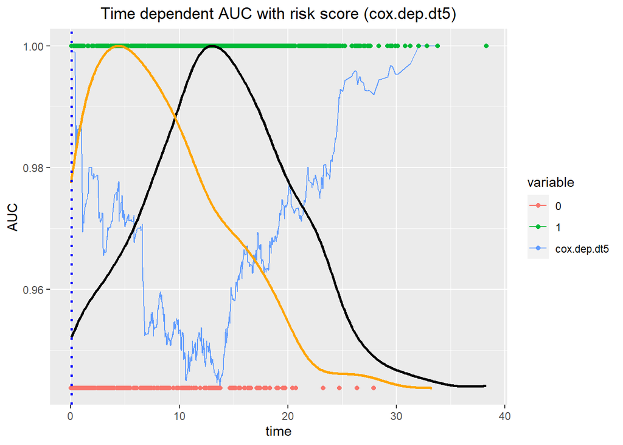

```r
dt5$censor1 <- ifelse(dt5$censor==1,
                    1,min(na.omit(ROC.risk.dep.dt5[["AUC"]])))
ggplot() +
  geom_line(data=res5, aes(x=time, y=value,
                            group=variable, color=variable)) +
  geom_point(data=dt5, aes(x=time, y=censor1, color=as.factor(censor))) +
  geom_line(data=data5_1, aes(x=time, y=density.adjusted),
            size=1, colour='black') +
  geom_line(data=data5_2, aes(x=time, y=density.adjusted),
            size=1, colour='orange') +
  scale_x_continuous(limits = c(0, max(dt5$time))) +
  geom_vline(xintercept = min(dt5$time[dt5$censor==1]),
             linetype="dotted", color = "blue", size=1) +
  ggtitle("Time dependent AUC with risk score (cox.dep.dt5)") +
  xlab("time") + ylab("AUC") +
  theme(plot.title = element_text(hjust = 0.5))
```

#### simulation (repeat 100 times / time VS mean of AUC)

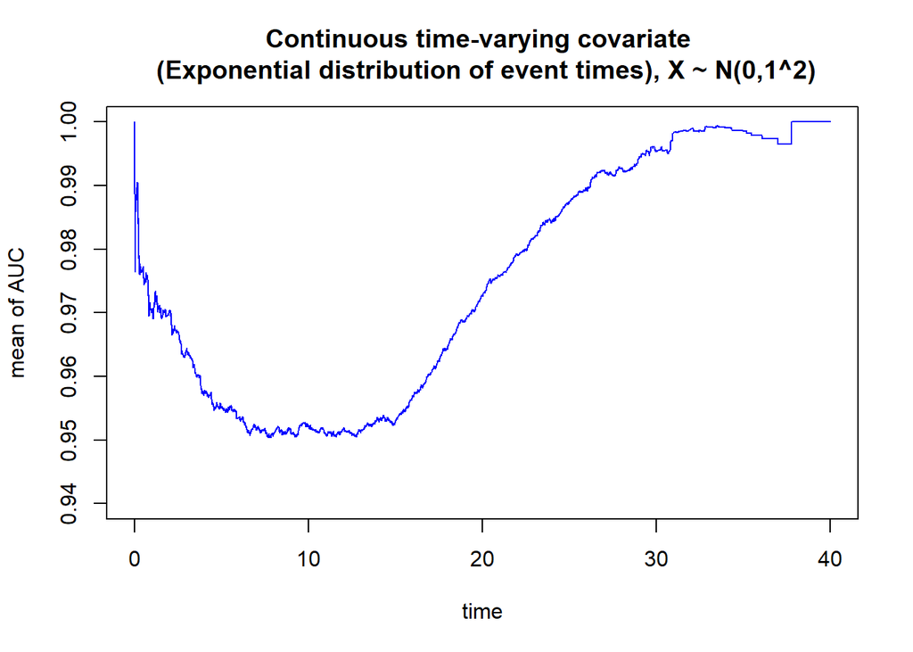

```r
con.AUC <- matrix(nrow=length(seq(0,40,0.01)),ncol=100)

for (i in 1:100) {

  lambda1 <- 0.003 # parameter for generate Y
  lambda2 <- 0.2/lambda1 # parameter for generate C
  beta0 <- 3 ; gamma0 <- 2 ; alpha0 <- 4 # true coefficients
  Y <- c() # real survival time
  C <- c() # censoring time
  t <- c() # observed survival time
  censor <- c() # censoring indicator
  X <- c() # time invariant covariate
  U1 <- c() # random variable from U(0,1) for generate Y
  U2 <- c() # random variable from U(0,1) for generate C

  # Generate simulation data
  set.seed(i)
  for (j in 1:200) {
    U1[j] <- runif(1)
    U2[j] <- runif(1)
    X[j] <- rnorm(1,mean=0,sd=1)
    Y[j] <- (1/gamma0*alpha0)*log(1-(gamma0*alpha0/lambda1/exp(beta0*X[j]))*log(U1[j]))
    C[j] <- (lambda2)*(1-U2[j])
    t[j] <- min(Y[j],C[j])
    censor[j] <- ifelse(Y[j]<=C[j],1,0)
  }
  dt5 <- data.frame(X=X, Y=Y, C=C, time=t, censor=censor)

  # Set Cox regression model
  cox.dep.dt5 <- coxph(Surv(time,censor) ~ X, data=dt5)
  summary(cox.dep.dt5)
  risk.dep.dt5 <- predict(object=cox.dep.dt5, newdata=dt5, type="risk") # risk score
  dt5$risk.dep.dt5 <- risk.dep.dt5
  ROC.risk.dep.dt5 <- timeROC(T=dt5$time,
                           delta=dt5$censor,marker=dt5$risk.dep.dt5,
                           cause=1,weighting="marginal",
                           times=seq(0,40,0.01))

  con.AUC[,i] <- ROC.risk.dep.dt5[["AUC"]]

  # print(i)

}

dat5 <- data.frame(time=seq(0,40,0.01), con.AUC=rowMeans(con.AUC, na.rm=TRUE))
plot(x=dat5$time, y=dat5$con.AUC, xlab="time", ylab="mean of AUC",
     main="Continuous time-varying covariate \n (Exponential distribution of event times), X ~ N(0,1^2)", type="l", col="blue", ylim=c(0.94,1))
```

## Case 3) X ~ Cauchy

- $X \sim Cauchy(0,1)$

## Generating simulation data

```r
lambda1 <- 0.003 # parameter for generate Y
lambda2 <- 0.2/lambda1 # parameter for generate C
beta0 <- 3 ; gamma0 <- 2 ; alpha0 <- 4 # true coefficients
Y <- c() # real survival time
C <- c() # censoring time
t <- c() # observed survival time
censor <- c() # censoring indicator
X <- c() # time invariant covariate
U1 <- c() # random variable from U(0,1) for generate Y
U2 <- c() # random variable from U(0,1) for generate C

for (i in 1:1000) {
  U1[i] <- runif(1)
  U2[i] <- runif(1)
  X[i] <- rcauchy(1,location=0,scale=1)
  Y[i] <- (1/gamma0*alpha0)*log(1-(gamma0*alpha0/lambda1/exp(beta0*X[i]))*log(U1[i]))
  C[i] <- (lambda2)*(1-U2[i])
  t[i] <- min(Y[i],C[i])
  censor[i] <- ifelse(Y[i]<=C[i],1,0)
}

mean(1-censor) # censoring rate
```

```
## [1] 0.269
```

```r
dt5 <- data.frame(X=X, Y=Y, C=C, time=t, censor=censor)
head(dt5,10)
```

```
##             X            Y         C         time censor
## 1   5.5872575 6.466706e-04 51.337728 6.466706e-04      1
## 2   0.1405805 1.411110e+01  5.007050 5.007050e+00      0
## 3   0.5212785 1.393799e+01 10.121741 1.012174e+01      0
## 4  -1.8979084 2.386840e+01  9.120525 9.120525e+00      0
## 5   0.5002505 1.545512e+01  0.137130 1.371300e-01      0
## 6   1.8753358 6.434900e+00 13.487119 6.434900e+00      1
## 7  -0.4673821 1.628195e+01 43.930028 1.628195e+01      1
## 8  -0.3195434 1.748045e+01 28.762635 1.748045e+01      1
## 9   3.6117899 7.015992e-03 10.186662 7.015992e-03      1
## 10 -0.3118593 1.775981e+01 36.206774 1.775981e+01      1
```

```r
min(dt5$time[dt5$censor==1])
```

```
## [1] 0
```

### Time dependent AUC

### Set Cox regression model

```r
cox.dep.dt5 <- coxph(Surv(time,censor) ~ X, data=dt5)
summary(cox.dep.dt5)
```

```
## Call:
## coxph(formula = Surv(time, censor) ~ X, data = dt5)
##
##   n= 1000, number of events= 731
##
##        coef exp(coef)  se(coef)     z Pr(>|z|)
## X 0.0010107 1.0010113 0.0001426 7.086 1.38e-12 ***
## ---
## Signif. codes:  0 '***' 0.001 '**' 0.01 '*' 0.05 '.' 0.1 ' ' 1
##
##   exp(coef) exp(-coef) lower .95 upper .95
## X     1.001      0.999     1.001     1.001
##
## Concordance= 0.941  (se = 0.004 )
## Likelihood ratio test= 24.23  on 1 df,   p=9e-07
## Wald test            = 50.21  on 1 df,   p=1e-12
## Score (logrank) test = 3  on 1 df,   p=0.08
```

```r
risk.dep.dt5 <- predict(object=cox.dep.dt5, newdata=dt5, type="risk") # risk score
dt5$risk.dep.dt5 <- risk.dep.dt5
ROC.risk.dep.dt5 <- timeROC(T=dt5$time,
                         delta=dt5$censor,marker=dt5$risk.dep.dt5,
                         cause=1,weighting="marginal",
                         times=dt5$time)
ROC.risk.dep.dt5
```

```
## Time-dependent-Roc curve estimated using IPCW  (n=1000, without competing risks).
##                    Cases Survivors Censored AUC (%)
## t=0                    0       973       27      NA
## t=4.66470779368039   185       749       66   99.13
## t=11.6790854083663   352       500      148   97.44
## t=17.5574936674938   552       250      198   98.59
## t=64.7617793641984   731         0      269      NA
##
## Method used for estimating IPCW:marginal
##
## Total computation time : 0.45  secs.
```

#### Make AUC data

```r
# uncensored
uncensored.density5 <- density(dt5$time[dt5$censor==1])
data5_1 <- data.frame(time=uncensored.density5[["x"]],
                    density=uncensored.density5[["y"]])
data5_1$density.adjusted <- (max(na.omit(ROC.risk.dep.dt5[["AUC"]]))-min(na.omit(ROC.risk.dep.dt5[["AUC"]])))*(uncensored.density5[["y"]]-min(uncensored.density5[["y"]]))/(max(uncensored.density5[["y"]])-min(uncensored.density5[["y"]]))+min(na.omit(ROC.risk.dep.dt5[["AUC"]]))

# censored
censored.density5 <- density(dt5$time[dt5$censor==0])
data5_2 <- data.frame(time=censored.density5[["x"]],
                    density=censored.density5[["y"]])
data5_2$density.adjusted <- (max(na.omit(ROC.risk.dep.dt5[["AUC"]]))-min(na.omit(ROC.risk.dep.dt5[["AUC"]])))*(censored.density5[["y"]]-min(censored.density5[["y"]]))/(max(censored.density5[["y"]])-min(censored.density5[["y"]]))+min(na.omit(ROC.risk.dep.dt5[["AUC"]]))

res5 <- data.frame(time=ROC.risk.dep.dt5[["times"]],
                    cox.dep.dt5=ROC.risk.dep.dt5[["AUC"]])
res5 <- melt(data = res5,
                   id.vars = "time",
                   measure.vars = c("cox.dep.dt5"))
```

#### Time dependent AUC plot with ggplot2 (cox.dep.dt5)

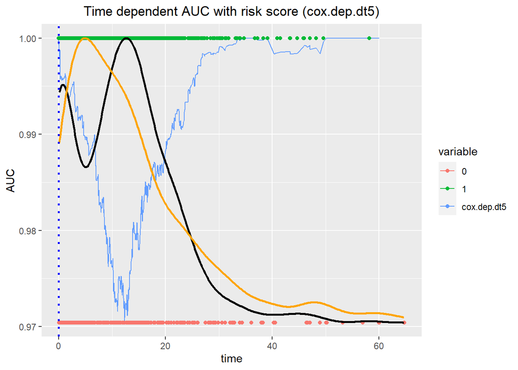

```r
dt5$censor1 <- ifelse(dt5$censor==1,
                    1,min(na.omit(ROC.risk.dep.dt5[["AUC"]])))
ggplot() +
  geom_line(data=res5, aes(x=time, y=value,
                            group=variable, color=variable)) +
  geom_point(data=dt5, aes(x=time, y=censor1, color=as.factor(censor))) +
  geom_line(data=data5_1, aes(x=time, y=density.adjusted),
            size=1, colour='black') +
  geom_line(data=data5_2, aes(x=time, y=density.adjusted),
            size=1, colour='orange') +
  scale_x_continuous(limits = c(0, max(dt5$time))) +
  geom_vline(xintercept = min(dt5$time[dt5$censor==1]),
             linetype="dotted", color = "blue", size=1) +
  ggtitle("Time dependent AUC with risk score (cox.dep.dt5)") +
  xlab("time") + ylab("AUC") +
  theme(plot.title = element_text(hjust = 0.5))
```

#### simulation (repeat 100 times / time VS mean of AUC)

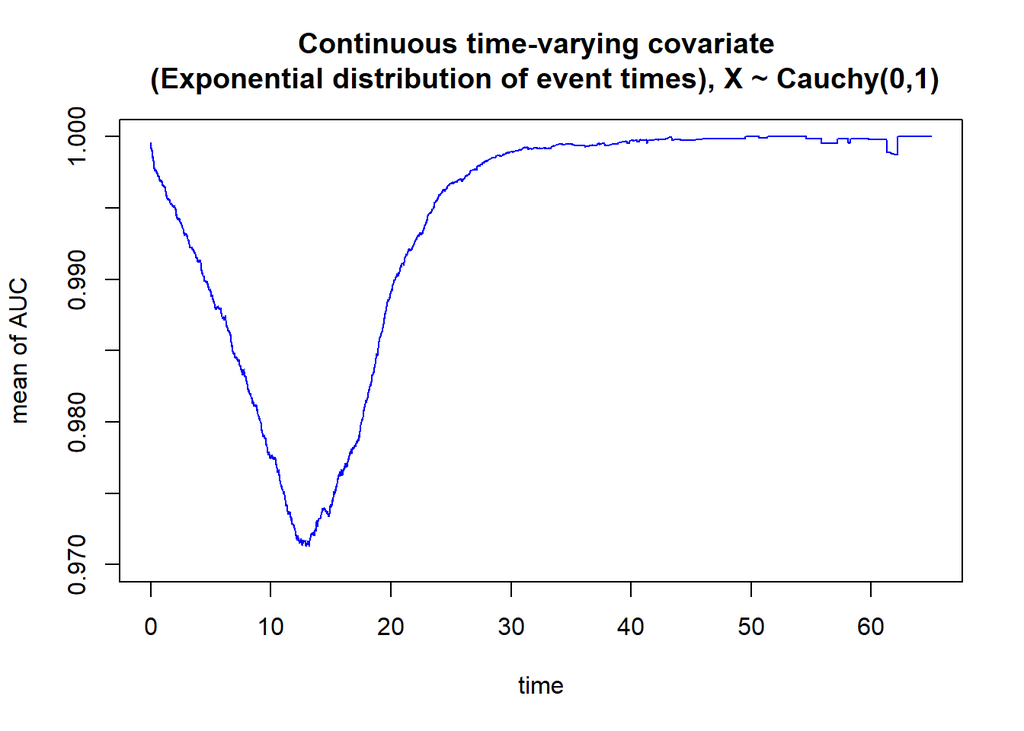

```r
con.AUC <- matrix(nrow=length(seq(0,65,0.01)),ncol=100)

for (i in 1:100) {

  lambda1 <- 0.003 # parameter for generate Y
  lambda2 <- 0.2/lambda1 # parameter for generate C
  beta0 <- 3 ; gamma0 <- 2 ; alpha0 <- 4 # true coefficients
  Y <- c() # real survival time
  C <- c() # censoring time
  t <- c() # observed survival time
  censor <- c() # censoring indicator
  X <- c() # time invariant covariate
  U1 <- c() # random variable from U(0,1) for generate Y
  U2 <- c() # random variable from U(0,1) for generate C

  # Generate simulation data
  set.seed(i)
  for (j in 1:200) {
    U1[j] <- runif(1)
    U2[j] <- runif(1)
    X[j] <- rcauchy(1,location=0,scale=1)
    Y[j] <- (1/gamma0*alpha0)*log(1-(gamma0*alpha0/lambda1/exp(beta0*X[j]))*log(U1[j]))
    C[j] <- (lambda2)*(1-U2[j])
    t[j] <- min(Y[j],C[j])
    censor[j] <- ifelse(Y[j]<=C[j],1,0)
  }
  dt5 <- data.frame(X=X, Y=Y, C=C, time=t, censor=censor)

  # Set Cox regression model
  cox.dep.dt5 <- coxph(Surv(time,censor) ~ X, data=dt5)
  summary(cox.dep.dt5)
  risk.dep.dt5 <- predict(object=cox.dep.dt5, newdata=dt5, type="risk") # risk score
  dt5$risk.dep.dt5 <- risk.dep.dt5
  ROC.risk.dep.dt5 <- timeROC(T=dt5$time,
                           delta=dt5$censor,marker=dt5$risk.dep.dt5,
                           cause=1,weighting="marginal",
                           times=seq(0,65,0.01))

  con.AUC[,i] <- ROC.risk.dep.dt5[["AUC"]]

  # print(i)

}

dat5 <- data.frame(time=seq(0,65,0.01), con.AUC=rowMeans(con.AUC, na.rm=TRUE))
plot(x=dat5$time, y=dat5$con.AUC, xlab="time", ylab="mean of AUC",
     main="Continuous time-varying covariate \n (Exponential distribution of event times), X ~ Cauchy(0,1)", type="l", col="blue", ylim=c(0.97,1))
```

## Case 4) X ~ Exponential

- $X \sim Exp(1)$

## Generating simulation data

```r
lambda1 <- 0.003 # parameter for generate Y
lambda2 <- 0.2/lambda1 # parameter for generate C
beta0 <- 3 ; gamma0 <- 2 ; alpha0 <- 4 # true coefficients
Y <- c() # real survival time
C <- c() # censoring time
t <- c() # observed survival time
censor <- c() # censoring indicator
X <- c() # time invariant covariate
U1 <- c() # random variable from U(0,1) for generate Y
U2 <- c() # random variable from U(0,1) for generate C

for (i in 1:1000) {
  U1[i] <- runif(1)
  U2[i] <- runif(1)
  X[i] <- rexp(1,rate=1)
  Y[i] <- (1/gamma0*alpha0)*log(1-(gamma0*alpha0/lambda1/exp(beta0*X[i]))*log(U1[i]))
  C[i] <- (lambda2)*(1-U2[i])
  t[i] <- min(Y[i],C[i])
  censor[i] <- ifelse(Y[i]<=C[i],1,0)
}

mean(1-censor) # censoring rate
```

```
## [1] 0.13
```

```r
dt5 <- data.frame(X=X, Y=Y, C=C, time=t, censor=censor)
head(dt5,10)
```

```
##            X         Y        C      time censor
## 1  1.6199331  8.561795 28.01963  8.561795      1
## 2  0.1784372 16.169281 56.80095 16.169281      1
## 3  0.2034422 12.882381 56.72038 12.882381      1
## 4  1.2818807  4.334007 23.53437  4.334007      1
## 5  0.3970893 15.913523 42.87606 15.913523      1
## 6  0.5485582 12.863351 13.00853 12.863351      1
## 7  0.9386417 11.036641 41.52244 11.036641      1
## 8  0.6717680  7.347832 38.90257  7.347832      1
## 9  0.2354258 14.619122 57.50689 14.619122      1
## 10 1.8759501  3.121929 48.50453  3.121929      1
```

```r
min(dt5$time[dt5$censor==1])
```

```
## [1] 3.84027e-05
```

### Time dependent AUC

### Set Cox regression model

```r
cox.dep.dt5 <- coxph(Surv(time,censor) ~ X, data=dt5)
summary(cox.dep.dt5)
```

```
## Call:
## coxph(formula = Surv(time, censor) ~ X, data = dt5)
##
##   n= 1000, number of events= 870
##
##       coef exp(coef) se(coef)     z Pr(>|z|)
## X  2.99455  19.97642  0.09066 33.03   <2e-16 ***
## ---
## Signif. codes:  0 '***' 0.001 '**' 0.01 '*' 0.05 '.' 0.1 ' ' 1
##
##   exp(coef) exp(-coef) lower .95 upper .95
## X     19.98    0.05006     16.72     23.86
##
## Concordance= 0.846  (se = 0.007 )
## Likelihood ratio test= 1525  on 1 df,   p=<2e-16
## Wald test            = 1091  on 1 df,   p=<2e-16
## Score (logrank) test = 2088  on 1 df,   p=<2e-16
```

```r
risk.dep.dt5 <- predict(object=cox.dep.dt5, newdata=dt5, type="risk") # risk score
dt5$risk.dep.dt5 <- risk.dep.dt5
ROC.risk.dep.dt5 <- timeROC(T=dt5$time,
                         delta=dt5$censor,marker=dt5$risk.dep.dt5,
                         cause=1,weighting="marginal",
                         times=dt5$time)
ROC.risk.dep.dt5
```

```
## Time-dependent-Roc curve estimated using IPCW  (n=1000, without competing risks).
##                       Cases Survivors Censored AUC (%)
## t=3.8402697396557e-05     0       999        1      NA
## t=4.60969001675646      204       749       47   93.94
## t=9.2635944670548       399       500      101   91.85
## t=12.6082145387192      626       250      124   89.03
## t=19.9959605912446      869         0      131      NA
##
## Method used for estimating IPCW:marginal
##
## Total computation time : 0.42  secs.
```

#### Make AUC data

```r
# uncensored
uncensored.density5 <- density(dt5$time[dt5$censor==1])
data5_1 <- data.frame(time=uncensored.density5[["x"]],
                    density=uncensored.density5[["y"]])
data5_1$density.adjusted <- (max(na.omit(ROC.risk.dep.dt5[["AUC"]]))-min(na.omit(ROC.risk.dep.dt5[["AUC"]])))*(uncensored.density5[["y"]]-min(uncensored.density5[["y"]]))/(max(uncensored.density5[["y"]])-min(uncensored.density5[["y"]]))+min(na.omit(ROC.risk.dep.dt5[["AUC"]]))

# censored
censored.density5 <- density(dt5$time[dt5$censor==0])
data5_2 <- data.frame(time=censored.density5[["x"]],
                    density=censored.density5[["y"]])
data5_2$density.adjusted <- (max(na.omit(ROC.risk.dep.dt5[["AUC"]]))-min(na.omit(ROC.risk.dep.dt5[["AUC"]])))*(censored.density5[["y"]]-min(censored.density5[["y"]]))/(max(censored.density5[["y"]])-min(censored.density5[["y"]]))+min(na.omit(ROC.risk.dep.dt5[["AUC"]]))

res5 <- data.frame(time=ROC.risk.dep.dt5[["times"]],
                    cox.dep.dt5=ROC.risk.dep.dt5[["AUC"]])
res5 <- melt(data = res5,
                   id.vars = "time",
                   measure.vars = c("cox.dep.dt5"))
```

#### Time dependent AUC plot with ggplot2 (cox.dep.dt5)

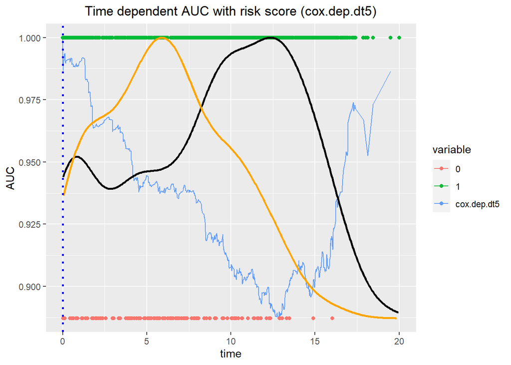

```r
dt5$censor1 <- ifelse(dt5$censor==1,
                    1,min(na.omit(ROC.risk.dep.dt5[["AUC"]])))
ggplot() +
  geom_line(data=res5, aes(x=time, y=value,
                            group=variable, color=variable)) +
  geom_point(data=dt5, aes(x=time, y=censor1, color=as.factor(censor))) +
  geom_line(data=data5_1, aes(x=time, y=density.adjusted),
            size=1, colour='black') +
  geom_line(data=data5_2, aes(x=time, y=density.adjusted),
            size=1, colour='orange') +
  scale_x_continuous(limits = c(0, max(dt5$time))) +
  geom_vline(xintercept = min(dt5$time[dt5$censor==1]),
             linetype="dotted", color = "blue", size=1) +
  ggtitle("Time dependent AUC with risk score (cox.dep.dt5)") +
  xlab("time") + ylab("AUC") +
  theme(plot.title = element_text(hjust = 0.5))
```

#### simulation (repeat 100 times / time VS mean of AUC)

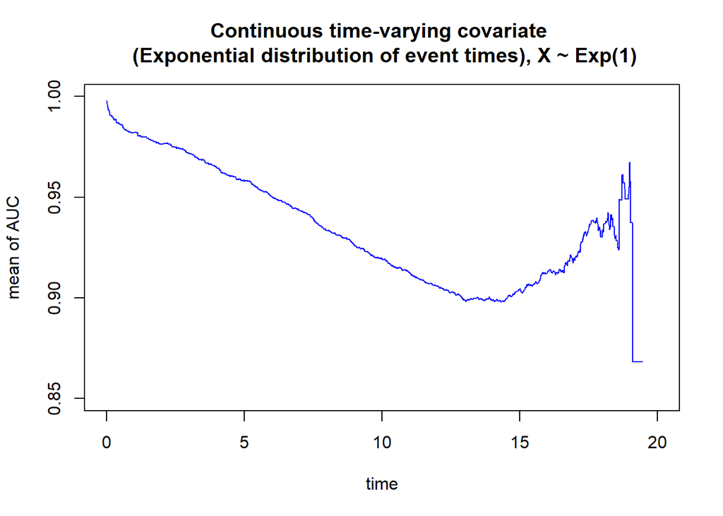

```r
con.AUC <- matrix(nrow=length(seq(0,20,0.01)),ncol=100)

for (i in 1:100) {

  lambda1 <- 0.003 # parameter for generate Y
  lambda2 <- 0.2/lambda1 # parameter for generate C
  beta0 <- 3 ; gamma0 <- 2 ; alpha0 <- 4 # true coefficients
  Y <- c() # real survival time
  C <- c() # censoring time
  t <- c() # observed survival time
  censor <- c() # censoring indicator
  X <- c() # time invariant covariate
  U1 <- c() # random variable from U(0,1) for generate Y
  U2 <- c() # random variable from U(0,1) for generate C

  # Generate simulation data
  set.seed(i)
  for (j in 1:200) {
    U1[j] <- runif(1)
    U2[j] <- runif(1)
    X[j] <- rexp(1,rate=1)
    Y[j] <- (1/gamma0*alpha0)*log(1-(gamma0*alpha0/lambda1/exp(beta0*X[j]))*log(U1[j]))
    C[j] <- (lambda2)*(1-U2[j])
    t[j] <- min(Y[j],C[j])
    censor[j] <- ifelse(Y[j]<=C[j],1,0)
  }
  dt5 <- data.frame(X=X, Y=Y, C=C, time=t, censor=censor)

  # Set Cox regression model
  cox.dep.dt5 <- coxph(Surv(time,censor) ~ X, data=dt5)
  summary(cox.dep.dt5)
  risk.dep.dt5 <- predict(object=cox.dep.dt5, newdata=dt5, type="risk") # risk score
  dt5$risk.dep.dt5 <- risk.dep.dt5
  ROC.risk.dep.dt5 <- timeROC(T=dt5$time,
                           delta=dt5$censor,marker=dt5$risk.dep.dt5,
                           cause=1,weighting="marginal",
                           times=seq(0,20,0.01))

  con.AUC[,i] <- ROC.risk.dep.dt5[["AUC"]]

  # print(i)

}

dat5 <- data.frame(time=seq(0,20,0.01), con.AUC=rowMeans(con.AUC, na.rm=TRUE))
plot(x=dat5$time, y=dat5$con.AUC, xlab="time", ylab="mean of AUC",
     main="Continuous time-varying covariate \n (Exponential distribution of event times), X ~ Exp(1)", type="l", col="blue", ylim=c(0.85,1))
```

## Case 2) Dichotomous time-varying covariate: exponential distribution of event times

- $Y$ : real survival time
- $C$ : censoring time
- model : $h(t,x,z(t))=h_{0}(t)exp(\beta x + \gamma z(t))$
- $Y$ : Assume $z(t)=\begin{cases} 0, & \mbox{if } t<t_{0} \\ 1, & \mbox{if } t \geq t_{0} \end{cases}$
- $h_{0}(t)=\lambda$
- If $t<t_{0}$, then $H(t,x,z(t))=\int_{0}^{t}h_{0}(s)exp(\gamma z(s) + \beta x)ds=\int_{0}^{t}\lambda exp(\beta x)ds=\lambda exp(\beta x)t$
- If $t \geq t_{0}$, then $H(t,x,z(t))=\int_{0}^{t}h_{0}(s)exp(\gamma z(s) + \beta x)ds=\int_{0}^{t} \lambda exp(\gamma z(s) + \beta x)ds=\lambda exp(\beta x) \int_{0}^{t}exp(\gamma z(s))ds=\lambda exp(\beta x) [ \int_{0}^{t_{0}}ds+\int_{t_{0}}^{t}exp(\gamma)ds ]=\lambda exp(\beta x)[t_{0}+exp(\gamma)t - exp(\gamma) t_{0}]$
- Hence, $H^{-1}(t,x,z(t))=\begin{cases} \frac {t}{\lambda exp(\beta x)}, & \mbox{if } t < \lambda exp(\beta x)t_{0} \\ \frac {t - \lambda exp(\beta x)t_{0} + \lambda exp(\beta x + \gamma)t_{0}}{\lambda exp(\beta x + \gamma)}, & \mbox{if } t \geq \lambda exp(\beta x)t_{0} \end{cases}$
- Therefore, $T=\begin{cases} \frac {-log(U)}{\lambda exp(\beta x)}, & \mbox{if } -log(U) < \lambda exp(\beta x)t_{0} \\ \frac {-log(U) - \lambda exp(\beta x)t_{0} + \lambda exp(\beta x + \gamma)t_{0}}{\lambda exp(\beta x + \gamma)}, & \mbox{if } -log(U) \geq \lambda exp(\beta x)t_{0} \end{cases}$ when $U \sim U(0,1)$
- $C$ : $f_{C0}(t)=\frac {1}{\lambda}, 0<t<\lambda$ -> $S_{C0}(t)=1-\frac {t}{\lambda}$ -> $h_{C0}(t)=\frac {1}{\lambda -t}$
- By Inverse Transform Sampling and non-informative censoring, suppose that $U_{1}, U_{2} \overset{i.i.d}{\sim}\ U(0,1)$, then we can generate real survival time $Y$ and censoring time $C$ like this.
- $\therefore Y=\begin{cases} \frac {-log(U_{1})}{\lambda exp(\beta x)}, & \mbox{if } -log(U_{1}) < \lambda exp(\beta x)t_{0} \\ \frac {-log(U_{1}) - \lambda exp(\beta x)t_{0} + \lambda exp(\beta x + \gamma)t_{0}}{\lambda exp(\beta x + \gamma)}, & \mbox{if } -log(U_{1}) \geq \lambda exp(\beta x)t_{0} \end{cases}$
- $\therefore C=\lambda_{2}(1-U_{2})$

## True model

- model : $h(t,x,z(t))=h_{0}(t)exp[\beta x + \gamma z(t)]$
- $z(t)=\begin{cases} 0, & \mbox{if } t<t_{0} \\ 1, & \mbox{if } t \geq t_{0} \end{cases}$
- $h_{0}(t)=\lambda$
- True coefficients : $\beta=3$, $\gamma=2$

## Case 1) X ~ Uniform

- $X \sim U(0,1)$

## Generating simulation data

```r
lambda1 <- 0.003 # parameter for generate Y
lambda2 <- 2.5/lambda1 # parameter for generate C
beta0 <- 3 ; gamma0 <- 2 # true coefficients
t0 <- 30 # denote the time at which the time-varying covariate changes from unexposed (Z(t) = 0) to exposed (Z(t) = 1)
Y <- c() # real survival time
C <- c() # censoring time
t <- c() # observed survival time
censor <- c() # censoring indicator
X <- c() # time invariant covariate
U1 <- c() # random variable from U(0,1) for generate Y
U2 <- c() # random variable from U(0,1) for generate C

for (i in 1:1000) {
  U1[i] <- runif(1)
  U2[i] <- runif(1)
  X[i] <- runif(1,min=0,max=1)
  Y[i] <- ifelse(-log(U1[i])<lambda1*exp(beta0*X[i])*t0, -log(U1[i])/lambda1/exp(beta0*X[i]), (-log(U1[i])-lambda1*exp(beta0*X[i])*t0+lambda1*exp(beta0*X[i]+gamma0)*t0)/lambda1/exp(beta0*X[i]+gamma0))
  C[i] <- (lambda2)*(1-U2[i])
  t[i] <- min(Y[i],C[i])
  censor[i] <- ifelse(Y[i]<=C[i],1,0)
}

mean(1-censor) # censoring rate
```

```
## [1] 0.044
```

```r
dt5 <- data.frame(X=X, Y=Y, C=C, time=t, censor=censor)
head(dt5,10)
```

```
##             X         Y         C      time censor
## 1  0.38075636 46.210826 342.38892 46.210826      1
## 2  0.59845486 19.317530 736.63269 19.317530      1
## 3  0.31616703 21.580175 540.94665 21.580175      1
## 4  0.84020015  6.652964 621.00840  6.652964      1
## 5  0.45804693 24.110129 576.01478 24.110129      1
## 6  0.13561655 52.360558 562.48665 52.360558      1
## 7  0.83792294  2.541920 708.01261  2.541920      1
## 8  0.04422934 49.971641 736.70604 49.971641      1
## 9  0.83694795 30.567824  98.94688 30.567824      1
## 10 0.31663633 75.692089 792.73249 75.692089      1
```

```r
min(dt5$time[dt5$censor==1])
```

```
## [1] 0.02425714
```

### Time dependent AUC

### Set Cox regression model

```r
cox.dep.dt5 <- coxph(Surv(time,censor) ~ X, data=dt5)
summary(cox.dep.dt5)
```

```
## Call:
## coxph(formula = Surv(time, censor) ~ X, data = dt5)
##
##   n= 1000, number of events= 956
##
##      coef exp(coef) se(coef)     z Pr(>|z|)
## X  3.0344   20.7876   0.1435 21.15   <2e-16 ***
## ---
## Signif. codes:  0 '***' 0.001 '**' 0.01 '*' 0.05 '.' 0.1 ' ' 1
##
##   exp(coef) exp(-coef) lower .95 upper .95
## X     20.79    0.04811     15.69     27.54
##
## Concordance= 0.712  (se = 0.008 )
## Likelihood ratio test= 465  on 1 df,   p=<2e-16
## Wald test            = 447.3  on 1 df,   p=<2e-16
## Score (logrank) test = 485.9  on 1 df,   p=<2e-16
```

```r
risk.dep.dt5 <- predict(object=cox.dep.dt5, newdata=dt5, type="risk") # risk score
dt5$risk.dep.dt5 <- risk.dep.dt5
ROC.risk.dep.dt5 <- timeROC(T=dt5$time,
                         delta=dt5$censor,marker=dt5$risk.dep.dt5,
                         cause=1,weighting="marginal",
                         times=dt5$time)
ROC.risk.dep.dt5
```

```
## Time-dependent-Roc curve estimated using IPCW  (n=1000, without competing risks).
##                     Cases Survivors Censored AUC (%)
## t=0.024257141381469     0       999        1      NA
## t=15.7700618479644    230       749       21   76.01
## t=31.9307683373661    465       500       35   79.75
## t=42.7468201225095    713       250       37   82.97
## t=172.796473047929    955         0       45      NA
##
## Method used for estimating IPCW:marginal
##
## Total computation time : 0.63  secs.
```

#### Make AUC data

```r
# uncensored
uncensored.density5 <- density(dt5$time[dt5$censor==1])
data5_1 <- data.frame(time=uncensored.density5[["x"]],
                    density=uncensored.density5[["y"]])
data5_1$density.adjusted <- (max(na.omit(ROC.risk.dep.dt5[["AUC"]]))-min(na.omit(ROC.risk.dep.dt5[["AUC"]])))*(uncensored.density5[["y"]]-min(uncensored.density5[["y"]]))/(max(uncensored.density5[["y"]])-min(uncensored.density5[["y"]]))+min(na.omit(ROC.risk.dep.dt5[["AUC"]]))

# censored
censored.density5 <- density(dt5$time[dt5$censor==0])
data5_2 <- data.frame(time=censored.density5[["x"]],
                    density=censored.density5[["y"]])
data5_2$density.adjusted <- (max(na.omit(ROC.risk.dep.dt5[["AUC"]]))-min(na.omit(ROC.risk.dep.dt5[["AUC"]])))*(censored.density5[["y"]]-min(censored.density5[["y"]]))/(max(censored.density5[["y"]])-min(censored.density5[["y"]]))+min(na.omit(ROC.risk.dep.dt5[["AUC"]]))

res5 <- data.frame(time=ROC.risk.dep.dt5[["times"]],
                    cox.dep.dt5=ROC.risk.dep.dt5[["AUC"]])
res5 <- melt(data = res5,
                   id.vars = "time",
                   measure.vars = c("cox.dep.dt5"))
```

#### Time dependent AUC plot with ggplot2 (cox.dep.dt5)

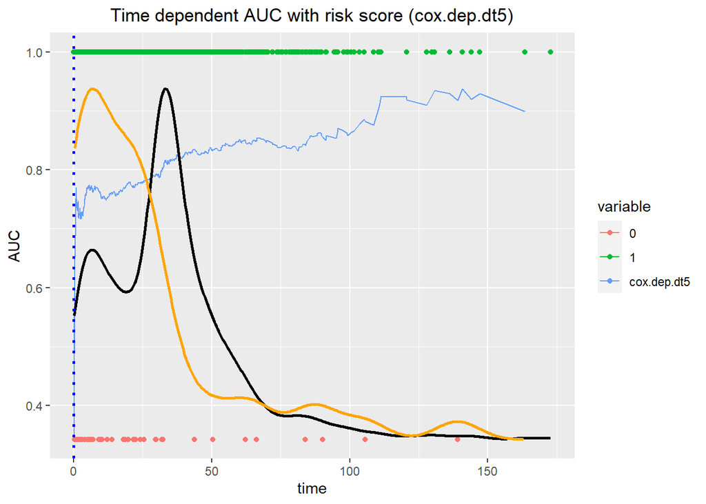

```r
dt5$censor1 <- ifelse(dt5$censor==1,
                    1,min(na.omit(ROC.risk.dep.dt5[["AUC"]])))
ggplot() +
  geom_line(data=res5, aes(x=time, y=value,
                            group=variable, color=variable)) +
  geom_point(data=dt5, aes(x=time, y=censor1, color=as.factor(censor))) +
  geom_line(data=data5_1, aes(x=time, y=density.adjusted),
            size=1, colour='black') +
  geom_line(data=data5_2, aes(x=time, y=density.adjusted),
            size=1, colour='orange') +
  scale_x_continuous(limits = c(0, max(dt5$time))) +
  geom_vline(xintercept = min(dt5$time[dt5$censor==1]),
             linetype="dotted", color = "blue", size=1) +
  ggtitle("Time dependent AUC with risk score (cox.dep.dt5)") +
  xlab("time") + ylab("AUC") +
  theme(plot.title = element_text(hjust = 0.5))
```

#### simulation (repeat 100 times / time VS mean of AUC)

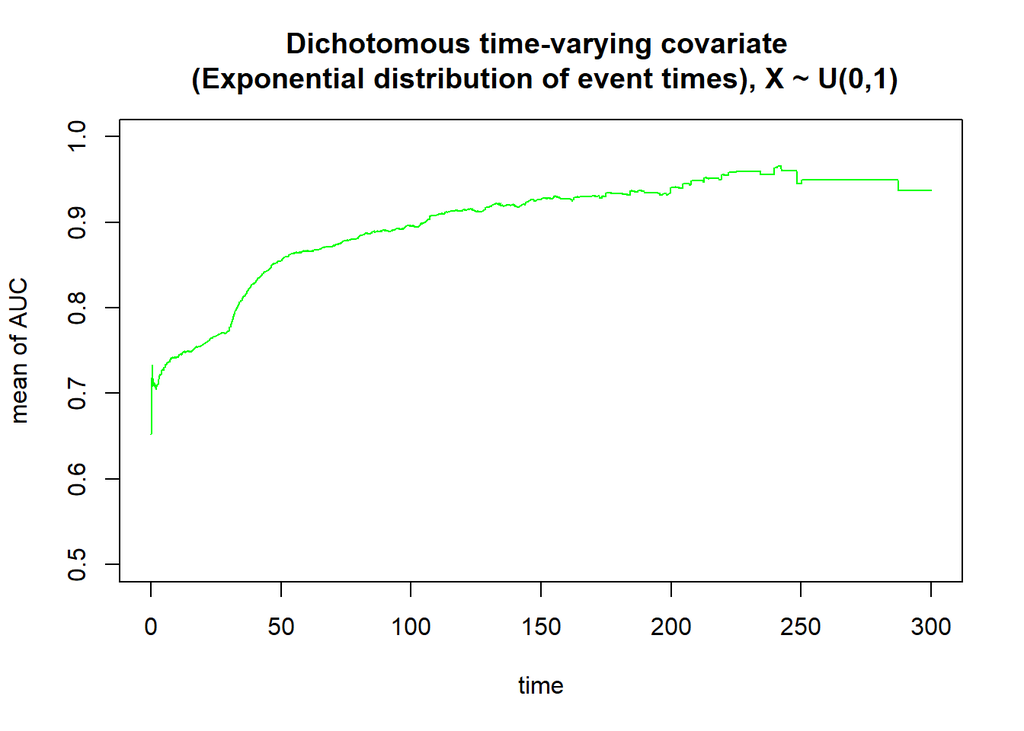

```r
con.AUC <- matrix(nrow=length(seq(0,300,0.1)),ncol=100)

for (i in 1:100) {

  lambda1 <- 0.003 # parameter for generate Y
  lambda2 <- 2.5/lambda1 # parameter for generate C
  beta0 <- 3 ; gamma0 <- 2 # true coefficients
  t0 <- 30 # denote the time at which the time-varying covariate changes from unexposed (Z(t) = 0) to exposed (Z(t) = 1)
  Y <- c() # real survival time
  C <- c() # censoring time
  t <- c() # observed survival time
  censor <- c() # censoring indicator
  X <- c() # time invariant covariate
  U1 <- c() # random variable from U(0,1) for generate Y
  U2 <- c() # random variable from U(0,1) for generate C

  # Generate simulation data
  set.seed(i)
  for (j in 1:200) {
    U1[j] <- runif(1)
    U2[j] <- runif(1)
    X[j] <- runif(1,min=0,max=1)
    Y[j] <- ifelse(-log(U1[j])<lambda1*exp(beta0*X[j])*t0, -log(U1[j])/lambda1/exp(beta0*X[j]), (-log(U1[j])-lambda1*exp(beta0*X[j])*t0+lambda1*exp(beta0*X[j]+gamma0)*t0)/lambda1/exp(beta0*X[j]+gamma0))
    C[j] <- (lambda2)*(1-U2[j])
    t[j] <- min(Y[j],C[j])
    censor[j] <- ifelse(Y[j]<=C[j],1,0)
  }
  dt5 <- data.frame(X=X, Y=Y, C=C, time=t, censor=censor)

  # Set Cox regression model
  cox.dep.dt5 <- coxph(Surv(time,censor) ~ X, data=dt5)
  summary(cox.dep.dt5)
  risk.dep.dt5 <- predict(object=cox.dep.dt5, newdata=dt5, type="risk") # risk score
  dt5$risk.dep.dt5 <- risk.dep.dt5
  ROC.risk.dep.dt5 <- timeROC(T=dt5$time,
                           delta=dt5$censor,marker=dt5$risk.dep.dt5,
                           cause=1,weighting="marginal",
                           times=seq(0,300,0.1))

  con.AUC[,i] <- ROC.risk.dep.dt5[["AUC"]]

  # print(i)

}

dat5 <- data.frame(time=seq(0,300,0.1), con.AUC=rowMeans(con.AUC, na.rm=TRUE))
plot(x=dat5$time, y=dat5$con.AUC, xlab="time", ylab="mean of AUC",
     main="Dichotomous time-varying covariate \n (Exponential distribution of event times), X ~ U(0,1)", type="l", col="green", ylim=c(0.5,1))
```

## Case 2) X ~ Normal

- $X \sim N(0,1^2)$

## Generating simulation data

```r
lambda1 <- 0.003 # parameter for generate Y
lambda2 <- 2.5/lambda1 # parameter for generate C
beta0 <- 3 ; gamma0 <- 2 # true coefficients
t0 <- 30 # denote the time at which the time-varying covariate changes from unexposed (Z(t) = 0) to exposed (Z(t) = 1)
Y <- c() # real survival time
C <- c() # censoring time
t <- c() # observed survival time
censor <- c() # censoring indicator
X <- c() # time invariant covariate
U1 <- c() # random variable from U(0,1) for generate Y
U2 <- c() # random variable from U(0,1) for generate C

for (i in 1:1000) {
  U1[i] <- runif(1)
  U2[i] <- runif(1)
  X[i] <- rnorm(1,mean=0,sd=1)
  Y[i] <- ifelse(-log(U1[i])<lambda1*exp(beta0*X[i])*t0, -log(U1[i])/lambda1/exp(beta0*X[i]), (-log(U1[i])-lambda1*exp(beta0*X[i])*t0+lambda1*exp(beta0*X[i]+gamma0)*t0)/lambda1/exp(beta0*X[i]+gamma0))
  C[i] <- (lambda2)*(1-U2[i])
  t[i] <- min(Y[i],C[i])
  censor[i] <- ifelse(Y[i]<=C[i],1,0)
}

mean(1-censor) # censoring rate
```

```
## [1] 0.263
```

```r
dt5 <- data.frame(X=X, Y=Y, C=C, time=t, censor=censor)
head(dt5,10)
```

```
##             X           Y         C       time censor
## 1  -1.0185647 3330.380332 350.24542 350.245423      0
## 2  -0.6512877  634.103361  72.21448  72.214477      0
## 3   1.0318997    6.519388 709.00469   6.519388      1
## 4   0.3771917   34.581714 105.72095  34.581714      1
## 5   0.5202194   59.307349 535.95069  59.307349      1
## 6  -0.8024887  134.693340 188.10074 134.693340      1
## 7  -0.2109543  125.050709  85.35519  85.355193      0
## 8   0.2994796   46.788581 718.83608  46.788581      1
## 9  -0.4390121  244.885925 678.16086 244.885925      1
## 10  0.7808050   32.208021  55.96114  32.208021      1
```

```r
min(dt5$time[dt5$censor==1])
```

```
## [1] 0.00337523
```

### Time dependent AUC

### Set Cox regression model

```r
cox.dep.dt5 <- coxph(Surv(time,censor) ~ X, data=dt5)
summary(cox.dep.dt5)
```

```
## Call:
## coxph(formula = Surv(time, censor) ~ X, data = dt5)
##
##   n= 1000, number of events= 737
##
##       coef exp(coef) se(coef)     z Pr(>|z|)
## X  2.99933  20.07204  0.08931 33.58   <2e-16 ***
## ---
## Signif. codes:  0 '***' 0.001 '**' 0.01 '*' 0.05 '.' 0.1 ' ' 1
##
##   exp(coef) exp(-coef) lower .95 upper .95
## X     20.07    0.04982     16.85     23.91
##
## Concordance= 0.89  (se = 0.005 )
## Likelihood ratio test= 1784  on 1 df,   p=<2e-16
## Wald test            = 1128  on 1 df,   p=<2e-16
## Score (logrank) test = 1287  on 1 df,   p=<2e-16
```

```r
risk.dep.dt5 <- predict(object=cox.dep.dt5, newdata=dt5, type="risk") # risk score
dt5$risk.dep.dt5 <- risk.dep.dt5
ROC.risk.dep.dt5 <- timeROC(T=dt5$time,
                         delta=dt5$censor,marker=dt5$risk.dep.dt5,
                         cause=1,weighting="marginal",
                         times=dt5$time)
ROC.risk.dep.dt5
```

```
## Time-dependent-Roc curve estimated using IPCW  (n=1000, without competing risks).
##                       Cases Survivors Censored AUC (%)
## t=0.00337522975378996     0       999        1      NA
## t=16.1692905808053      226       749       25   95.52
## t=43.6014882476248      455       500       45   95.07
## t=147.504551875834      655       250       95   96.40
## t=828.281722885246      737         0      263      NA
##
## Method used for estimating IPCW:marginal
##
## Total computation time : 0.43  secs.
```

#### Make AUC data

```r
# uncensored
uncensored.density5 <- density(dt5$time[dt5$censor==1])
data5_1 <- data.frame(time=uncensored.density5[["x"]],
                    density=uncensored.density5[["y"]])
data5_1$density.adjusted <- (max(na.omit(ROC.risk.dep.dt5[["AUC"]]))-min(na.omit(ROC.risk.dep.dt5[["AUC"]])))*(uncensored.density5[["y"]]-min(uncensored.density5[["y"]]))/(max(uncensored.density5[["y"]])-min(uncensored.density5[["y"]]))+min(na.omit(ROC.risk.dep.dt5[["AUC"]]))

# censored
censored.density5 <- density(dt5$time[dt5$censor==0])
data5_2 <- data.frame(time=censored.density5[["x"]],
                    density=censored.density5[["y"]])
data5_2$density.adjusted <- (max(na.omit(ROC.risk.dep.dt5[["AUC"]]))-min(na.omit(ROC.risk.dep.dt5[["AUC"]])))*(censored.density5[["y"]]-min(censored.density5[["y"]]))/(max(censored.density5[["y"]])-min(censored.density5[["y"]]))+min(na.omit(ROC.risk.dep.dt5[["AUC"]]))

res5 <- data.frame(time=ROC.risk.dep.dt5[["times"]],
                    cox.dep.dt5=ROC.risk.dep.dt5[["AUC"]])
res5 <- melt(data = res5,
                   id.vars = "time",
                   measure.vars = c("cox.dep.dt5"))
```

#### Time dependent AUC plot with ggplot2 (cox.dep.dt5)

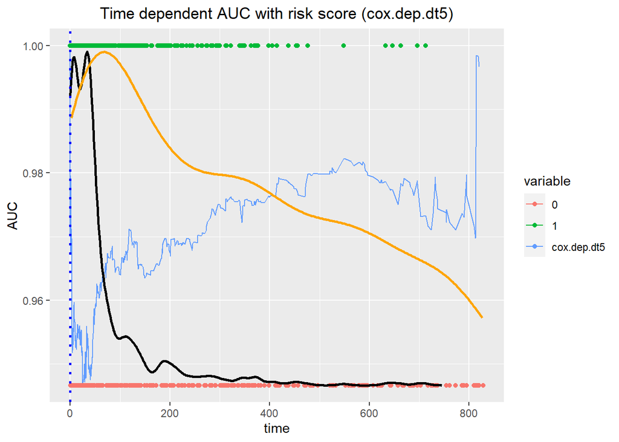

```r
dt5$censor1 <- ifelse(dt5$censor==1,
                    1,min(na.omit(ROC.risk.dep.dt5[["AUC"]])))
ggplot() +
  geom_line(data=res5, aes(x=time, y=value,
                            group=variable, color=variable)) +
  geom_point(data=dt5, aes(x=time, y=censor1, color=as.factor(censor))) +
  geom_line(data=data5_1, aes(x=time, y=density.adjusted),
            size=1, colour='black') +
  geom_line(data=data5_2, aes(x=time, y=density.adjusted),
            size=1, colour='orange') +
  scale_x_continuous(limits = c(0, max(dt5$time))) +
  geom_vline(xintercept = min(dt5$time[dt5$censor==1]),
             linetype="dotted", color = "blue", size=1) +
  ggtitle("Time dependent AUC with risk score (cox.dep.dt5)") +
  xlab("time") + ylab("AUC") +
  theme(plot.title = element_text(hjust = 0.5))
```

#### simulation (repeat 100 times / time VS mean of AUC)

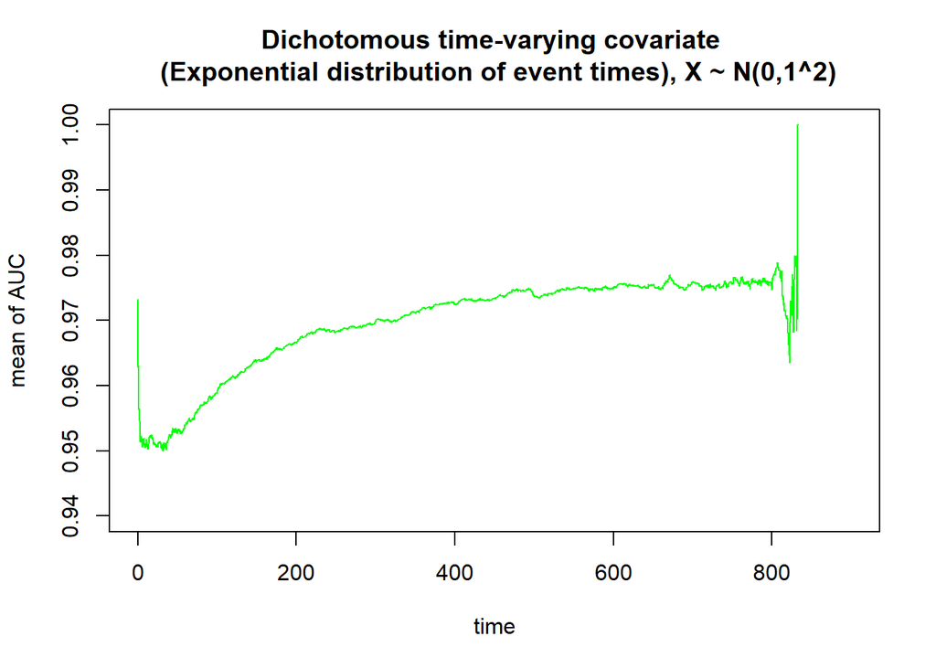

```r
con.AUC <- matrix(nrow=length(seq(0,900,0.1)),ncol=100)

for (i in 1:100) {

  lambda1 <- 0.003 # parameter for generate Y
  lambda2 <- 2.5/lambda1 # parameter for generate C
  beta0 <- 3 ; gamma0 <- 2 # true coefficients
  t0 <- 30 # denote the time at which the time-varying covariate changes from unexposed (Z(t) = 0) to exposed (Z(t) = 1)
  Y <- c() # real survival time
  C <- c() # censoring time
  t <- c() # observed survival time
  censor <- c() # censoring indicator
  X <- c() # time invariant covariate
  U1 <- c() # random variable from U(0,1) for generate Y
  U2 <- c() # random variable from U(0,1) for generate C

  # Generate simulation data
  set.seed(i)
  for (j in 1:200) {
    U1[j] <- runif(1)
    U2[j] <- runif(1)
    X[j] <- rnorm(1,mean=0,sd=1)
    Y[j] <- ifelse(-log(U1[j])<lambda1*exp(beta0*X[j])*t0, -log(U1[j])/lambda1/exp(beta0*X[j]), (-log(U1[j])-lambda1*exp(beta0*X[j])*t0+lambda1*exp(beta0*X[j]+gamma0)*t0)/lambda1/exp(beta0*X[j]+gamma0))
    C[j] <- (lambda2)*(1-U2[j])
    t[j] <- min(Y[j],C[j])
    censor[j] <- ifelse(Y[j]<=C[j],1,0)
  }
  dt5 <- data.frame(X=X, Y=Y, C=C, time=t, censor=censor)

  # Set Cox regression model
  cox.dep.dt5 <- coxph(Surv(time,censor) ~ X, data=dt5)
  summary(cox.dep.dt5)
  risk.dep.dt5 <- predict(object=cox.dep.dt5, newdata=dt5, type="risk") # risk score
  dt5$risk.dep.dt5 <- risk.dep.dt5
  ROC.risk.dep.dt5 <- timeROC(T=dt5$time,
                           delta=dt5$censor,marker=dt5$risk.dep.dt5,
                           cause=1,weighting="marginal",
                           times=seq(0,900,0.1))

  con.AUC[,i] <- ROC.risk.dep.dt5[["AUC"]]

  # print(i)

}

dat5 <- data.frame(time=seq(0,900,0.1), con.AUC=rowMeans(con.AUC, na.rm=TRUE))
plot(x=dat5$time, y=dat5$con.AUC, xlab="time", ylab="mean of AUC",
     main="Dichotomous time-varying covariate \n (Exponential distribution of event times), X ~ N(0,1^2)", type="l", col="green", ylim=c(0.94,1))
```

## Case 3) X ~ Cauchy

- $X \sim Cauchy(0,1)$

## Generating simulation data

```r
lambda1 <- 0.003 # parameter for generate Y
lambda2 <- 2.5/lambda1 # parameter for generate C
beta0 <- 3 ; gamma0 <- 2 # true coefficients
t0 <- 30 # denote the time at which the time-varying covariate changes from unexposed (Z(t) = 0) to exposed (Z(t) = 1)
Y <- c() # real survival time
C <- c() # censoring time
t <- c() # observed survival time
censor <- c() # censoring indicator
X <- c() # time invariant covariate
U1 <- c() # random variable from U(0,1) for generate Y
U2 <- c() # random variable from U(0,1) for generate C

for (i in 1:1000) {
  U1[i] <- runif(1)
  U2[i] <- runif(1)
  X[i] <- rcauchy(1,location=0,scale=1)
  Y[i] <- ifelse(-log(U1[i])<lambda1*exp(beta0*X[i])*t0, -log(U1[i])/lambda1/exp(beta0*X[i]), (-log(U1[i])-lambda1*exp(beta0*X[i])*t0+lambda1*exp(beta0*X[i]+gamma0)*t0)/lambda1/exp(beta0*X[i]+gamma0))
  C[i] <- (lambda2)*(1-U2[i])
  t[i] <- min(Y[i],C[i])
  censor[i] <- ifelse(Y[i]<=C[i],1,0)
}

mean(1-censor) # censoring rate
```

```
## [1] 0.318
```

```r
dt5 <- data.frame(X=X, Y=Y, C=C, time=t, censor=censor)
head(dt5,10)
```

```
##             X            Y          C         time censor
## 1   5.5872575 4.042345e-05 641.721604 4.042345e-05      1
## 2   0.1405805 4.553436e+01  62.588128 4.553436e+01      1
## 3   0.5212785 4.390830e+01 126.521763 4.390830e+01      1
## 4  -1.8979084 2.603897e+03 114.006567 1.140066e+02      0
## 5   0.5002505 6.432539e+01   1.714126 1.714126e+00      0
## 6   1.8753358 2.995547e+00 168.588982 2.995547e+00      1
## 7  -0.4673821 8.398636e+01 549.125346 8.398636e+01      1
## 8  -0.3195434 1.316422e+02 359.532940 1.316422e+02      1
## 9   3.6117899 4.392696e-04 127.333279 4.392696e-04      1
## 10 -0.3118593 1.474899e+02 452.584674 1.474899e+02      1
```

```r
min(dt5$time[dt5$censor==1])
```

```
## [1] 0
```

### Time dependent AUC

### Set Cox regression model

```r
cox.dep.dt5 <- coxph(Surv(time,censor) ~ X, data=dt5)
summary(cox.dep.dt5)
```

```
## Call:
## coxph(formula = Surv(time, censor) ~ X, data = dt5)
##
##   n= 1000, number of events= 682
##
##        coef exp(coef)  se(coef)     z Pr(>|z|)
## X 0.0009582 1.0009587 0.0001448 6.618 3.65e-11 ***
## ---
## Signif. codes:  0 '***' 0.001 '**' 0.01 '*' 0.05 '.' 0.1 ' ' 1
##
##   exp(coef) exp(-coef) lower .95 upper .95
## X     1.001      0.999     1.001     1.001
##
## Concordance= 0.934  (se = 0.004 )
## Likelihood ratio test= 19.7  on 1 df,   p=9e-06
## Wald test            = 43.79  on 1 df,   p=4e-11
## Score (logrank) test = 1.7  on 1 df,   p=0.2
```

```r
risk.dep.dt5 <- predict(object=cox.dep.dt5, newdata=dt5, type="risk") # risk score
dt5$risk.dep.dt5 <- risk.dep.dt5
ROC.risk.dep.dt5 <- timeROC(T=dt5$time,
                         delta=dt5$censor,marker=dt5$risk.dep.dt5,
                         cause=1,weighting="marginal",
                         times=dt5$time)
ROC.risk.dep.dt5
```

```
## Time-dependent-Roc curve estimated using IPCW  (n=1000, without competing risks).
##                    Cases Survivors Censored AUC (%)
## t=0                    0       997        3      NA
## t=6.26394866905552   239       749       12   98.38
## t=39.7593057429556   455       500       45   97.26
## t=182.381554429109   639       250      111   98.47
## t=832.418012820805   682         0      318      NA
##
## Method used for estimating IPCW:marginal
##
## Total computation time : 0.41  secs.
```

#### Make AUC data

```r
# uncensored
uncensored.density5 <- density(dt5$time[dt5$censor==1])
data5_1 <- data.frame(time=uncensored.density5[["x"]],
                    density=uncensored.density5[["y"]])
data5_1$density.adjusted <- (max(na.omit(ROC.risk.dep.dt5[["AUC"]]))-min(na.omit(ROC.risk.dep.dt5[["AUC"]])))*(uncensored.density5[["y"]]-min(uncensored.density5[["y"]]))/(max(uncensored.density5[["y"]])-min(uncensored.density5[["y"]]))+min(na.omit(ROC.risk.dep.dt5[["AUC"]]))

# censored
censored.density5 <- density(dt5$time[dt5$censor==0])
data5_2 <- data.frame(time=censored.density5[["x"]],
                    density=censored.density5[["y"]])
data5_2$density.adjusted <- (max(na.omit(ROC.risk.dep.dt5[["AUC"]]))-min(na.omit(ROC.risk.dep.dt5[["AUC"]])))*(censored.density5[["y"]]-min(censored.density5[["y"]]))/(max(censored.density5[["y"]])-min(censored.density5[["y"]]))+min(na.omit(ROC.risk.dep.dt5[["AUC"]]))

res5 <- data.frame(time=ROC.risk.dep.dt5[["times"]],
                    cox.dep.dt5=ROC.risk.dep.dt5[["AUC"]])
res5 <- melt(data = res5,
                   id.vars = "time",
                   measure.vars = c("cox.dep.dt5"))
```

#### Time dependent AUC plot with ggplot2 (cox.dep.dt5)

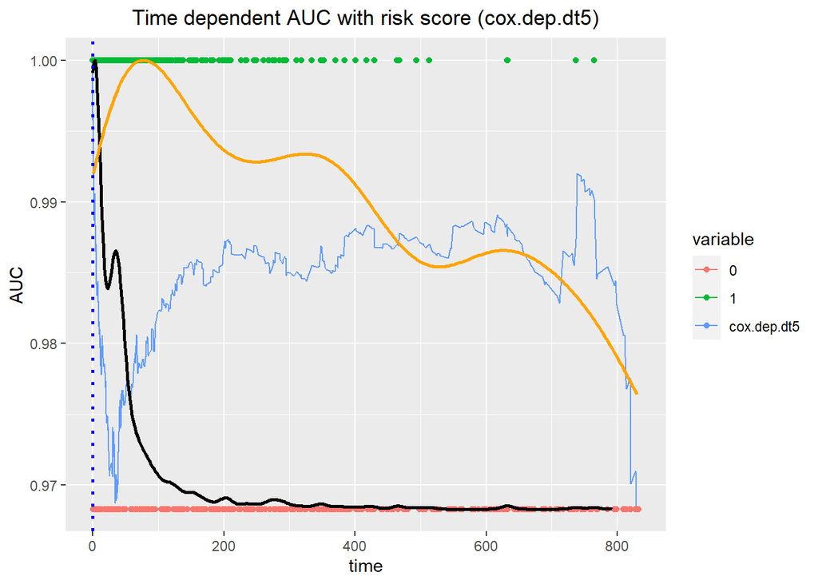

```r
dt5$censor1 <- ifelse(dt5$censor==1,
                    1,min(na.omit(ROC.risk.dep.dt5[["AUC"]])))
ggplot() +
  geom_line(data=res5, aes(x=time, y=value,
                            group=variable, color=variable)) +
  geom_point(data=dt5, aes(x=time, y=censor1, color=as.factor(censor))) +
  geom_line(data=data5_1, aes(x=time, y=density.adjusted),
            size=1, colour='black') +
  geom_line(data=data5_2, aes(x=time, y=density.adjusted),
            size=1, colour='orange') +
  scale_x_continuous(limits = c(0, max(dt5$time))) +
  geom_vline(xintercept = min(dt5$time[dt5$censor==1]),
             linetype="dotted", color = "blue", size=1) +
  ggtitle("Time dependent AUC with risk score (cox.dep.dt5)") +
  xlab("time") + ylab("AUC") +
  theme(plot.title = element_text(hjust = 0.5))
```

#### simulation (repeat 100 times / time VS mean of AUC)

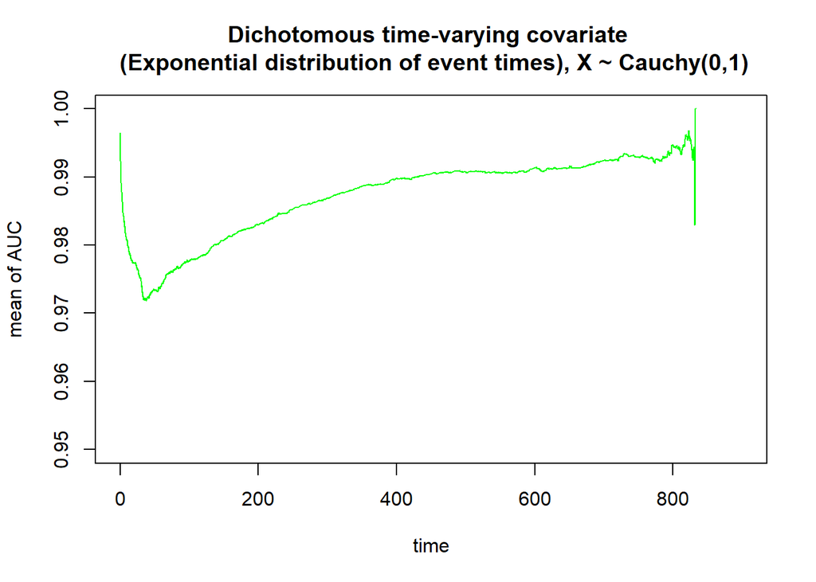

```r
con.AUC <- matrix(nrow=length(seq(0,900,0.1)),ncol=100)

for (i in 1:100) {

  lambda1 <- 0.003 # parameter for generate Y
  lambda2 <- 2.5/lambda1 # parameter for generate C
  beta0 <- 3 ; gamma0 <- 2 # true coefficients
  t0 <- 30 # denote the time at which the time-varying covariate changes from unexposed (Z(t) = 0) to exposed (Z(t) = 1)
  Y <- c() # real survival time
  C <- c() # censoring time
  t <- c() # observed survival time
  censor <- c() # censoring indicator
  X <- c() # time invariant covariate
  U1 <- c() # random variable from U(0,1) for generate Y
  U2 <- c() # random variable from U(0,1) for generate C

  # Generate simulation data
  set.seed(i)
  for (j in 1:200) {
    U1[j] <- runif(1)
    U2[j] <- runif(1)
    X[j] <- rcauchy(1,location=0,scale=1)
    Y[j] <- ifelse(-log(U1[j])<lambda1*exp(beta0*X[j])*t0, -log(U1[j])/lambda1/exp(beta0*X[j]), (-log(U1[j])-lambda1*exp(beta0*X[j])*t0+lambda1*exp(beta0*X[j]+gamma0)*t0)/lambda1/exp(beta0*X[j]+gamma0))
    C[j] <- (lambda2)*(1-U2[j])
    t[j] <- min(Y[j],C[j])
    censor[j] <- ifelse(Y[j]<=C[j],1,0)
  }
  dt5 <- data.frame(X=X, Y=Y, C=C, time=t, censor=censor)

  # Set Cox regression model
  cox.dep.dt5 <- coxph(Surv(time,censor) ~ X, data=dt5)
  summary(cox.dep.dt5)
  risk.dep.dt5 <- predict(object=cox.dep.dt5, newdata=dt5, type="risk") # risk score
  dt5$risk.dep.dt5 <- risk.dep.dt5
  ROC.risk.dep.dt5 <- timeROC(T=dt5$time,
                           delta=dt5$censor,marker=dt5$risk.dep.dt5,
                           cause=1,weighting="marginal",
                           times=seq(0,900,0.1))

  con.AUC[,i] <- ROC.risk.dep.dt5[["AUC"]]

  # print(i)

}

dat5 <- data.frame(time=seq(0,900,0.1), con.AUC=rowMeans(con.AUC, na.rm=TRUE))
plot(x=dat5$time, y=dat5$con.AUC, xlab="time", ylab="mean of AUC",
     main="Dichotomous time-varying covariate \n (Exponential distribution of event times), X ~ Cauchy(0,1)", type="l", col="green", ylim=c(0.95,1))
```

## Case 4) X ~ Exponential

- $X \sim Exp(1)$

## Generating simulation data

```r
lambda1 <- 0.003 # parameter for generate Y
lambda2 <- 2.5/lambda1 # parameter for generate C
beta0 <- 3 ; gamma0 <- 2 # true coefficients
t0 <- 30 # denote the time at which the time-varying covariate changes from unexposed (Z(t) = 0) to exposed (Z(t) = 1)
Y <- c() # real survival time
C <- c() # censoring time
t <- c() # observed survival time
censor <- c() # censoring indicator
X <- c() # time invariant covariate
U1 <- c() # random variable from U(0,1) for generate Y
U2 <- c() # random variable from U(0,1) for generate C

for (i in 1:1000) {
  U1[i] <- runif(1)
  U2[i] <- runif(1)
  X[i] <- rexp(1,rate=1)
  Y[i] <- ifelse(-log(U1[i])<lambda1*exp(beta0*X[i])*t0, -log(U1[i])/lambda1/exp(beta0*X[i]), (-log(U1[i])-lambda1*exp(beta0*X[i])*t0+lambda1*exp(beta0*X[i]+gamma0)*t0)/lambda1/exp(beta0*X[i]+gamma0))
  C[i] <- (lambda2)*(1-U2[i])
  t[i] <- min(Y[i],C[i])
  censor[i] <- ifelse(Y[i]<=C[i],1,0)
}

mean(1-censor) # censoring rate
```

```
## [1] 0.022
```

```r
dt5 <- data.frame(X=X, Y=Y, C=C, time=t, censor=censor)
head(dt5,10)
```

```
##            X          Y        C       time censor
## 1  1.6199331  8.9131625 350.2454  8.9131625      1
## 2  0.1784372 80.8057735 710.0118 80.8057735      1
## 3  0.2034422 36.5325132 709.0047 36.5325132      1
## 4  1.2818807  0.9665096 294.1796  0.9665096      1
## 5  0.3970893 74.2176420 535.9507 74.2176420      1
## 6  0.5485582 36.4320425 162.6067 36.4320425      1
## 7  0.9386417 30.1389924 519.0305 30.1389924      1
## 8  0.6717680  4.8007404 486.2821  4.8007404      1
## 9  0.2354258 51.2056957 718.8361 51.2056957      1
## 10 1.8759501  0.4704266 606.3066  0.4704266      1
```

```r
min(dt5$time[dt5$censor==1])
```

```
## [1] 2.400192e-06
```

### Time dependent AUC

### Set Cox regression model

```r
cox.dep.dt5 <- coxph(Surv(time,censor) ~ X, data=dt5)
summary(cox.dep.dt5)
```

```
## Call:
## coxph(formula = Surv(time, censor) ~ X, data = dt5)
##
##   n= 1000, number of events= 978
##
##       coef exp(coef) se(coef)    z Pr(>|z|)
## X  2.98159  19.71908  0.08693 34.3   <2e-16 ***
## ---
## Signif. codes:  0 '***' 0.001 '**' 0.01 '*' 0.05 '.' 0.1 ' ' 1
##
##   exp(coef) exp(-coef) lower .95 upper .95
## X     19.72    0.05071     16.63     23.38
##
## Concordance= 0.832  (se = 0.007 )
## Likelihood ratio test= 1608  on 1 df,   p=<2e-16
## Wald test            = 1176  on 1 df,   p=<2e-16
## Score (logrank) test = 2188  on 1 df,   p=<2e-16
```

```r
risk.dep.dt5 <- predict(object=cox.dep.dt5, newdata=dt5, type="risk") # risk score
dt5$risk.dep.dt5 <- risk.dep.dt5
ROC.risk.dep.dt5 <- timeROC(T=dt5$time,
                         delta=dt5$censor,marker=dt5$risk.dep.dt5,
                         cause=1,weighting="marginal",
                         times=dt5$time)
ROC.risk.dep.dt5
```

```
## Time-dependent-Roc curve estimated using IPCW  (n=1000, without competing risks).
##                        Cases Survivors Censored AUC (%)
## t=2.40019163067318e-06     0       999        1      NA
## t=2.03767092576269       247       749        4   93.92
## t=18.9610779488414       486       500       14   91.13
## t=37.4926290759465       731       250       19   88.68
## t=397.790950720613       977         0       23      NA
##
## Method used for estimating IPCW:marginal
##
## Total computation time : 0.62  secs.
```

#### Make AUC data

```r
# uncensored
uncensored.density5 <- density(dt5$time[dt5$censor==1])
data5_1 <- data.frame(time=uncensored.density5[["x"]],
                    density=uncensored.density5[["y"]])
data5_1$density.adjusted <- (max(na.omit(ROC.risk.dep.dt5[["AUC"]]))-min(na.omit(ROC.risk.dep.dt5[["AUC"]])))*(uncensored.density5[["y"]]-min(uncensored.density5[["y"]]))/(max(uncensored.density5[["y"]])-min(uncensored.density5[["y"]]))+min(na.omit(ROC.risk.dep.dt5[["AUC"]]))

# censored
censored.density5 <- density(dt5$time[dt5$censor==0])
data5_2 <- data.frame(time=censored.density5[["x"]],
                    density=censored.density5[["y"]])
data5_2$density.adjusted <- (max(na.omit(ROC.risk.dep.dt5[["AUC"]]))-min(na.omit(ROC.risk.dep.dt5[["AUC"]])))*(censored.density5[["y"]]-min(censored.density5[["y"]]))/(max(censored.density5[["y"]])-min(censored.density5[["y"]]))+min(na.omit(ROC.risk.dep.dt5[["AUC"]]))

res5 <- data.frame(time=ROC.risk.dep.dt5[["times"]],
                    cox.dep.dt5=ROC.risk.dep.dt5[["AUC"]])
res5 <- melt(data = res5,
                   id.vars = "time",
                   measure.vars = c("cox.dep.dt5"))
```

#### Time dependent AUC plot with ggplot2 (cox.dep.dt5)

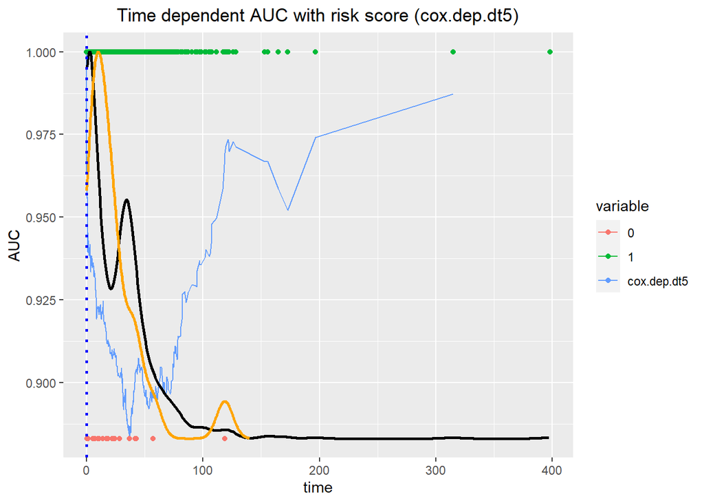

```r
dt5$censor1 <- ifelse(dt5$censor==1,
                    1,min(na.omit(ROC.risk.dep.dt5[["AUC"]])))
ggplot() +
  geom_line(data=res5, aes(x=time, y=value,
                            group=variable, color=variable)) +
  geom_point(data=dt5, aes(x=time, y=censor1, color=as.factor(censor))) +
  geom_line(data=data5_1, aes(x=time, y=density.adjusted),
            size=1, colour='black') +
  geom_line(data=data5_2, aes(x=time, y=density.adjusted),
            size=1, colour='orange') +
  scale_x_continuous(limits = c(0, max(dt5$time))) +
  geom_vline(xintercept = min(dt5$time[dt5$censor==1]),
             linetype="dotted", color = "blue", size=1) +
  ggtitle("Time dependent AUC with risk score (cox.dep.dt5)") +
  xlab("time") + ylab("AUC") +
  theme(plot.title = element_text(hjust = 0.5))
```

#### simulation (repeat 100 times / time VS mean of AUC)

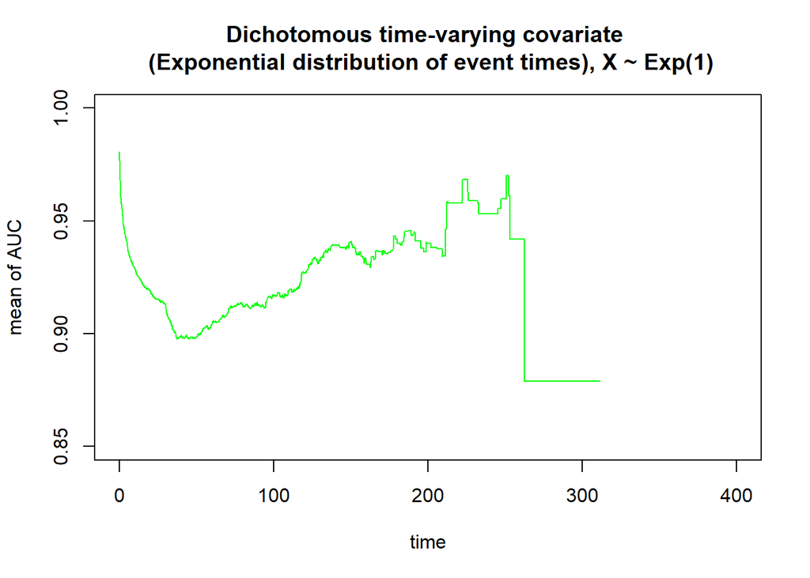

```r
con.AUC <- matrix(nrow=length(seq(0,400,0.1)),ncol=100)

for (i in 1:100) {

  lambda1 <- 0.003 # parameter for generate Y
  lambda2 <- 2.5/lambda1 # parameter for generate C
  beta0 <- 3 ; gamma0 <- 2 # true coefficients
  t0 <- 30 # denote the time at which the time-varying covariate changes from unexposed (Z(t) = 0) to exposed (Z(t) = 1)
  Y <- c() # real survival time
  C <- c() # censoring time
  t <- c() # observed survival time
  censor <- c() # censoring indicator
  X <- c() # time invariant covariate
  U1 <- c() # random variable from U(0,1) for generate Y
  U2 <- c() # random variable from U(0,1) for generate C

  # Generate simulation data
  set.seed(i)
  for (j in 1:200) {
    U1[j] <- runif(1)
    U2[j] <- runif(1)
    X[j] <- rexp(1,rate=1)
    Y[j] <- ifelse(-log(U1[j])<lambda1*exp(beta0*X[j])*t0, -log(U1[j])/lambda1/exp(beta0*X[j]), (-log(U1[j])-lambda1*exp(beta0*X[j])*t0+lambda1*exp(beta0*X[j]+gamma0)*t0)/lambda1/exp(beta0*X[j]+gamma0))
    C[j] <- (lambda2)*(1-U2[j])
    t[j] <- min(Y[j],C[j])
    censor[j] <- ifelse(Y[j]<=C[j],1,0)
  }
  dt5 <- data.frame(X=X, Y=Y, C=C, time=t, censor=censor)

  # Set Cox regression model
  cox.dep.dt5 <- coxph(Surv(time,censor) ~ X, data=dt5)
  summary(cox.dep.dt5)
  risk.dep.dt5 <- predict(object=cox.dep.dt5, newdata=dt5, type="risk") # risk score
  dt5$risk.dep.dt5 <- risk.dep.dt5
  ROC.risk.dep.dt5 <- timeROC(T=dt5$time,
                           delta=dt5$censor,marker=dt5$risk.dep.dt5,
                           cause=1,weighting="marginal",
                           times=seq(0,400,0.1))

  con.AUC[,i] <- ROC.risk.dep.dt5[["AUC"]]

  # print(i)

}

dat5 <- data.frame(time=seq(0,400,0.1), con.AUC=rowMeans(con.AUC, na.rm=TRUE))
plot(x=dat5$time, y=dat5$con.AUC, xlab="time", ylab="mean of AUC",
     main="Dichotomous time-varying covariate \n (Exponential distribution of event times), X ~ Exp(1)", type="l", col="green", ylim=c(0.85,1))
```